# FLicc user guide

## 8.6 Residual diagnostics

FLicc is an equilibrium model: each year’s composition is explained by the equilibrium at that year’s F. Strong and weak year classes growing through the compositions are therefore expected to leave patterns in the residuals. The aim of the diagnostics is not to remove these patterns but to see them and judge their size, and to separate them from misfit that a setting can fix (selectivity, Linf, tail, effective sample size).

**Residuals.** `resid_flicc()` computes residuals consistent with the likelihood of the fit (effective sample size, observation model, tail cut, plus group):

- Pearson residuals, $r = (o - n\pi)/\sqrt{V}$, with $V = n\pi(1-\pi)$ for the multinomial and the same times $(n+\alpha_0)/(1+\alpha_0)$ for the Dirichlet-multinomial. They are easy to read in bubble plots but correlated within a composition and not normal for small expected counts.
- One-step-ahead (OSA) residuals: the composition is split, along increasing length, into a sequence of conditional binomials (beta-binomials for the Dirichlet-multinomial), and each observed count is turned into a randomized quantile residual $r = \Phi^{-1}(u)$. Under a correct model they are independent standard normal (Trijoulet et al. 2023), so QQ plots and tests are valid.

**How OSA residuals work.** A composition is not a set of independent numbers: with $n$ fish measured, a high count in one bin forces lower counts elsewhere. OSA residuals step through the bins of one composition, from small to large, and ask at each step a conditional question:

- bin 1: of all $n$ fish, how many should be in bin 1? Binomial$(n, \pi_1)$;
- bin 2: of the fish not in bin 1, how many should be in bin 2? Binomial$(n - o_1, \pi_2/(1-\pi_1))$; and so on. The last bin is determined by the others and has no residual.

The observed count is located in its predicted distribution: at the 97.5th percentile, $u = 0.975$ and $r = \Phi^{-1}(0.975) = 1.96$. Because counts are whole numbers, $u$ is drawn at random within the step of the distribution where the count falls (the “randomized” part). For the Dirichlet-multinomial the binomials are beta-binomials, so its extra variance is included.

“One step ahead” refers to stepping through the bins, not through time. In models with random effects, OSA residuals step through time and re-estimate the random effects at each step. FLicc has no random effects by default (F is estimated each year, the random walk is a penalty), so the expected compositions are fixed once the model is fitted and the residuals are exact and cheap.

Reading them:

- **Size**: about 5% beyond $\pm 2$, almost none beyond $\pm 3$.
- **Sign**: each residual is conditional on the smaller bins. A positive residual at length $L$ means that, of the fish still present at $L$ or larger, more were in bin $L$ than predicted: fish “drop out” faster than the model expects (higher mortality or falling selectivity), as in a catch curve. A negative residual means more fish carried on to larger sizes.
- **Spread**: an sd well above 1 means the data are noisier than the effective sample size and observation model allow (intervals too narrow); well below 1, that the noise is overstated.
- **Process variation**: the model does not include year-class strength, so strong and weak year classes appear as structure in the residuals (runs along the cohort tracks, mean-length runs) rather than as noise.
- **Few data per parameter**: residuals are computed at parameters estimated from the same data, so they shrink towards zero (sd below 1) when there are few data per parameter, e.g. a fit to a single year. A single year also gives no between-year diagnostics, and a year-class bump within one composition cannot be told apart from a selectivity misfit at those lengths. Across years, cohorts move along the growth tracks while selectivity misfit stays at the same length; the joint fit with shared selectivity is what lets the residuals separate the two.

```r
res_osa <- resid_flicc(fit, type = "osa")
c(mean = mean(res_osa$resid, na.rm = TRUE), sd = sd(res_osa$resid, na.rm = TRUE))
```

```
#>       mean         sd
#> 0.05655158 0.99622117
```

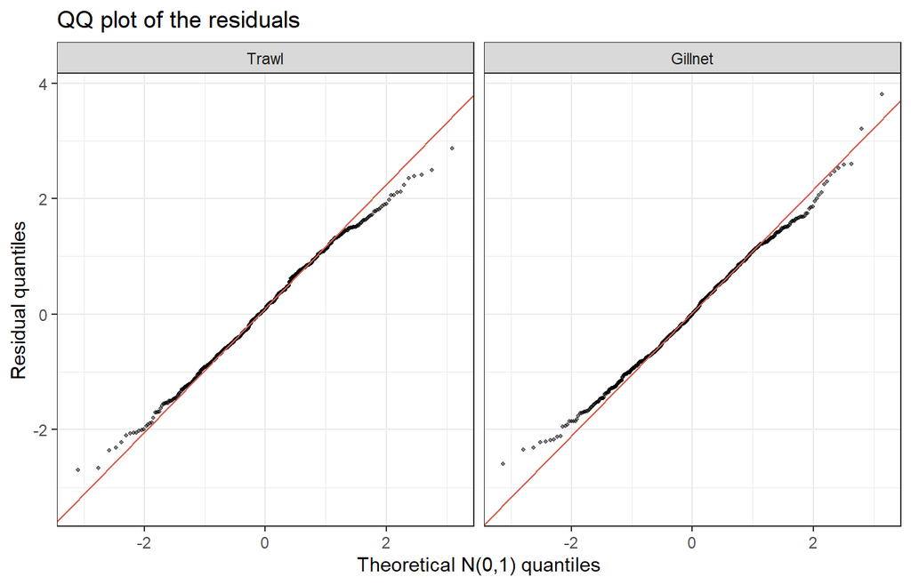

```r
plot_resid_qq(res_osa)
```

**Bubble plots.** Residuals by length and year; blue where more fish were observed than expected, red where fewer. `cohorts = TRUE` adds von Bertalanffy growth tracks of year classes (grey lines):

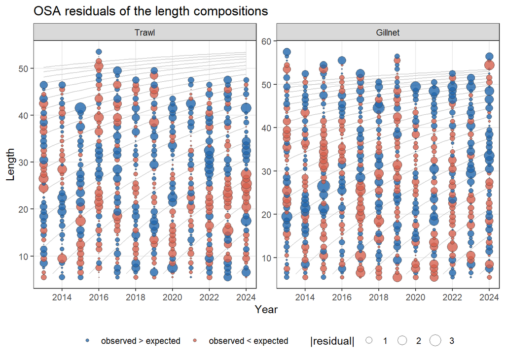

```r
plot_resid_bubble(res_osa, fit = fit, cohorts = TRUE)
```

**Residuals by length.** `plot_resid_len()` draws the residuals against length as bars, with the same panels as `plot_len()`: one panel per year and gear (`year =`, `gear =` select them), the gears pooled with `by_gear = FALSE`, or the years pooled with `pool_years = TRUE`. Pooled residuals are summed and divided by $\sqrt{k}$ (for $k$ residuals per bin), so the dashed lines at $\pm 2$ keep their meaning.

Pooled over all years, year classes largely cancel out, and what remains is misfit at the same lengths in every year: the selectivity shape, or Linf and CVL in the largest fish. This is the first plot to look at:

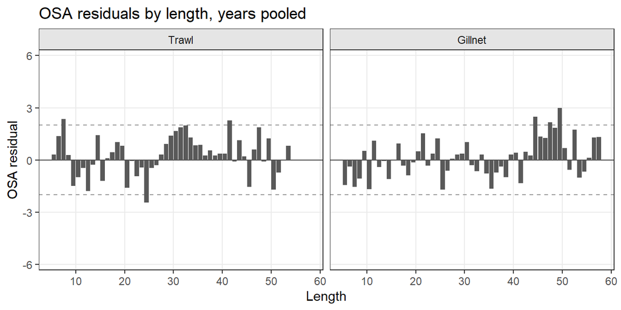

```r
plot_resid_len(res_osa, pool_years = TRUE)
```

Here two runs stand out. In the trawl, the OSA residuals are positive from about 28 to 35 cm: of the fish at these lengths or larger, more stop at each length than predicted, i.e. the trawl catches fewer fish above 35 cm than the fitted dome allows (its right limb falls more steeply). In the gillnet, positive residuals from about 45 to 50 cm say the same for the largest fish: fewer reach the largest lengths than predicted, which points to Linf or CVL (the growth of the largest fish), to a slight dome of the gillnet, or to a higher F on the largest fish. Both runs are at the same lengths in every year (below), so they are not year classes.

By year, a misfit that moves to larger lengths from one year to the next is a year class growing through; one that stays at the same length is selectivity. The last three years, as OSA and as Pearson residuals:

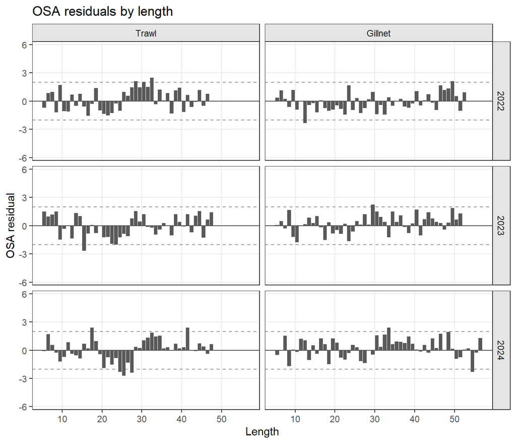

```r
plot_resid_len(res_osa, year = 2022:2024)
```

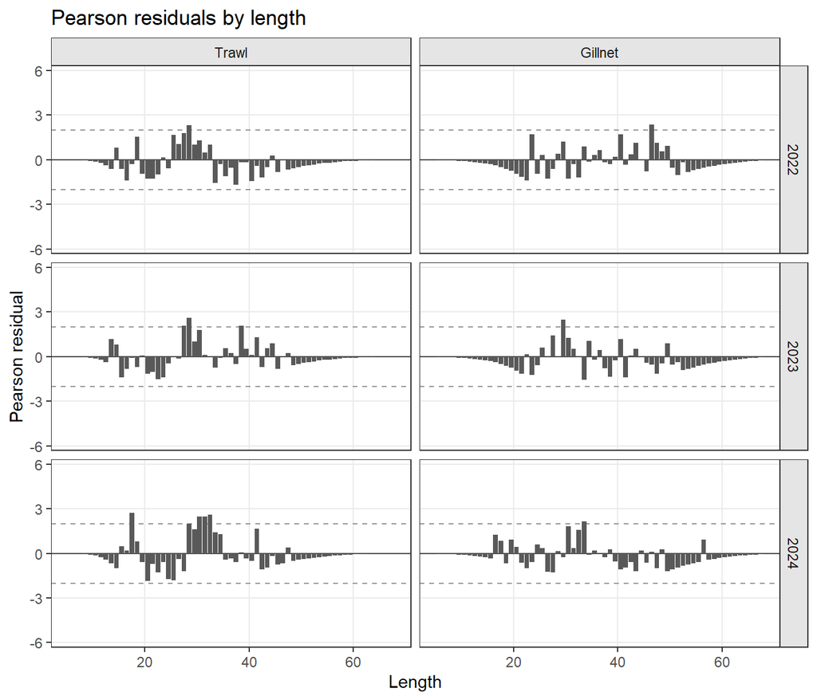

```r
plot_resid_len(fit, type = "pearson", year = 2022:2024)
```

The trawl run at about 30-35 cm is there in all three years, together with a deficit at about 20-28 cm, as OSA and as Pearson residuals: a shape the trawl selectivity does not follow, not a year class (which would move by a few cm per year). In the Pearson panels, the long rows of small negative bars at both ends of each panel are the empty bins beyond the observed fish: they carry no information.

**Pearson or OSA?** Both measure how far the observed count in a bin is from its expectation, in standard deviations, but they answer different questions:

|  | Pearson | OSA |
| --- | --- | --- |
| Question | Is the count in this bin far from $n\pi$? | Given the fish in the smaller bins, is the count in this bin unusual? |
| Independence | correlated within a composition (they sum to about zero: a misfit at one length forces opposite residuals elsewhere) | independent under a correct model |
| Distribution | skewed for small expected counts: observed zeros give small negative values, one fish where 0.05 are expected gives about +4 | standard normal, also for small counts |
| Tails | drawn for every bin, so the empty bins beyond the largest fish form a fringe of small negative bars | end at the largest fish of each composition (and the last bin has none) |
| Randomness | none | a random draw within each count’s step (`seed`): small details change with the seed, patterns do not |
| Use | bubble plots, a quick look at where the fit is high or low | QQ plot, sd, tests, the $\pm 2$ rule |

In practice: read patterns with either, judge size and significance with OSA. A pattern that shows in both (e.g. too few fish at one range of lengths and too many at the next) is real. A single large Pearson residual at the largest lengths that is small as OSA residual is one rare fish, not a misfit.

The sign of an OSA residual is conditional: a positive residual at length $L$ means that, of the fish at $L$ or larger, more were in bin $L$ than predicted. A run of negative OSA residuals followed by a run of positive ones therefore marks a dip followed by a surplus in the composition, e.g. a second mode or a year class at the larger lengths.

**Mean length and runs test.** The observed mean length of each composition is compared with its expectation, standardized with the standard error implied by the observation model (Francis 2011). A runs test checks whether the residuals change sign as often as random residuals would; too few runs mean systematic structure (green background: passed; red: failed; limits at three standard deviations, as in `ss3diags` and JABBA):

```r
lmr <- lmean_resid_flicc(fit)
lmr$runs
```

```
#>            gear p_value pass sd_z
#> Trawl     Trawl   0.409 TRUE 1.29
#> Gillnet Gillnet   0.965 TRUE 1.09
```

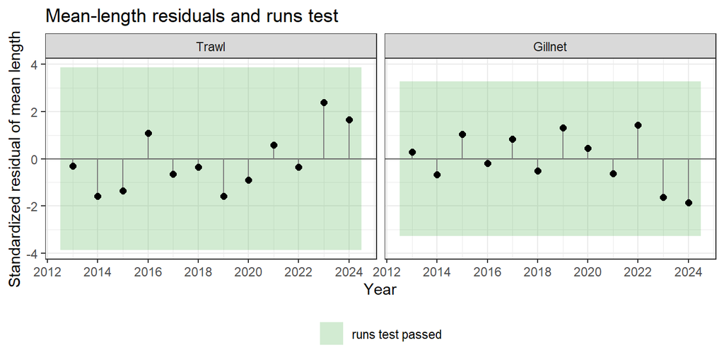

```r
lmr$plot
```

**Posterior predictive checks.** `ppc_flicc()` simulates compositions from the fitted model (at the effective sample size and with the observation model of the fit) and compares observed statistics with their predictive distribution: mean length, 95th percentile, proportion of mature fish and largest length. With `par_draws = TRUE` the parameters are also drawn from their estimated uncertainty.

```r
ppc <- ppc_flicc(fit, nsim = 300)
ppc$coverage
```

```
#>      gear  stat share_outside_95
#> 1   Trawl Lmean             0.08
#> 2 Gillnet Lmean             0.08
#> 3   Trawl   L95             0.08
#> 4 Gillnet   L95             0.08
#> 5   Trawl  Pmat             0.08
#> 6 Gillnet  Pmat             0.00
#> 7   Trawl  Lmax             0.00
#> 8 Gillnet  Lmax             0.25
```

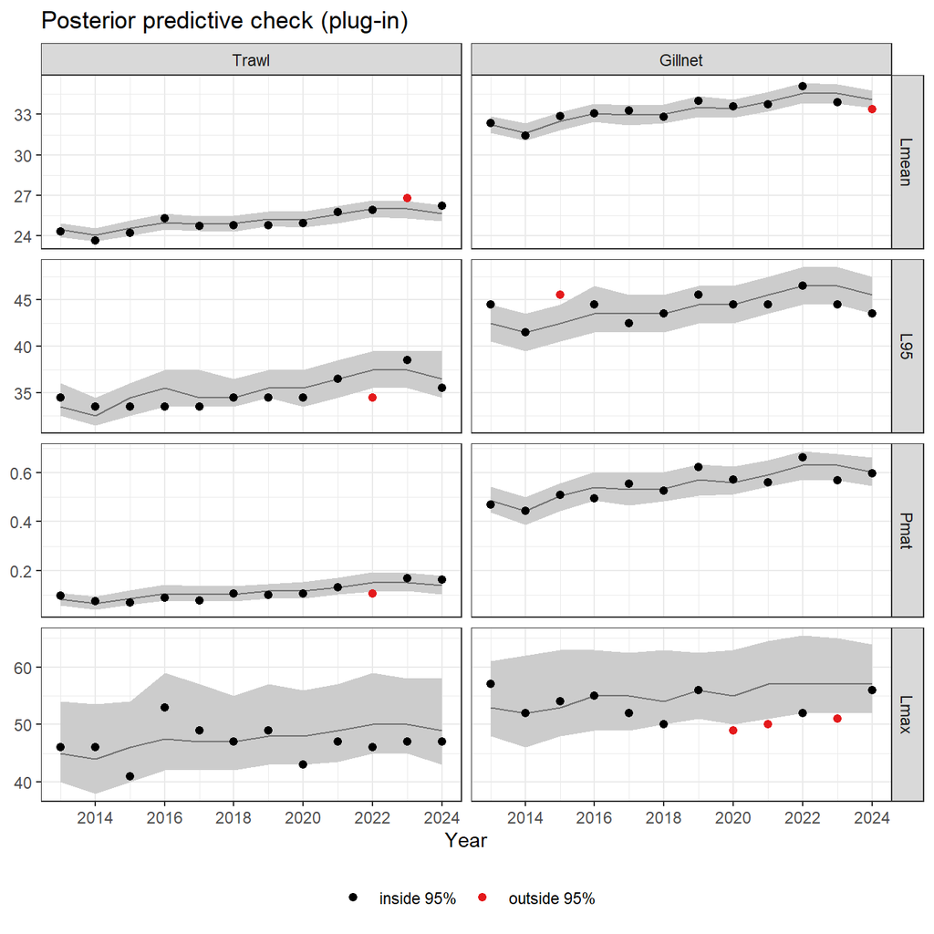

```r
ppc$plot
```

In this fit the OSA residuals have sd 1, so the bin-to-bin noise within a year is close to what the observation model allows. The mean lengths, however, vary between years with an sd of 1.29 (trawl) and 1.09 (gillnet) in standardized units, and 8% and 8% of the observed mean lengths lie outside their 95% predictive intervals. Where the between-year variation is large while the within-year noise is not, the misfit is not sampling noise: whole compositions shift between years, as year classes pass through, which the equilibrium model cannot follow.

About 5% of the observed values should lie outside the 95% intervals. Many more means that the effective sample size or the observation model understate the variability of the data, so the intervals of the assessment are too narrow; far fewer means the effective sample size could be higher.

| Pattern | Likely cause | Response |
| --- | --- | --- |
| Diagonal runs of one sign along the cohort tracks; mean-length runs test failed | strong or weak year classes (expected in an equilibrium model) | report it; check that status is robust (retrospective, tail cut); do not over-fit |
| Vertical bands of one sign at the same lengths in all years | selectivity shape | logistic vs dome; dome sensitivity |
| Misfit of the largest fish in all years | Linf, CVL or doming | Linf sensitivity, tail cut |
| A change of sign between periods | change of selectivity, gear or sampling | split periods; `by_year` check |
| Many observed statistics outside the predictive intervals | ESS too high, or observation model too narrow | lower ESS; Dirichlet-multinomial |
| OSA residuals with sd well above 1 | the same | the same |

## 8.7 Check 9: retrospective consistency

The model is refitted with the last one, two and three years removed (`peels`); `Map()` runs one fit per peel. Mohn’s rho compares the terminal SPR of each peel with the SPR of the same year in the full fit.

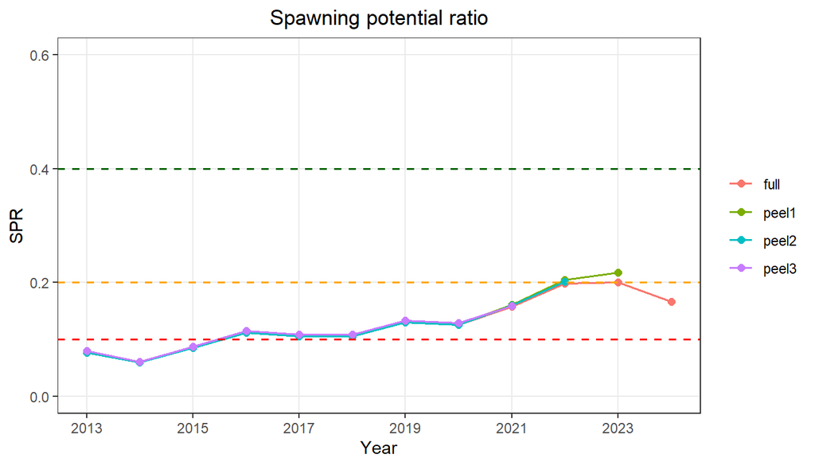

```r
yrs <- as.numeric(dimnames(lfd[[1]])$year)
peels <- 1:3

retro <- Map(function(p) {
  fiticc(lfd, stklen, sel_fun = sel_fun, catch_by_gear = cbg,
         settings = list(CVL = 0.1, obs_model = "dm", dm_theta = "saturating"),
         years = head(yrs, -p), se = FALSE)
}, peels)
names(retro) <- paste0("peel", peels)
plot_spr(c(list(full = fit), retro))
```

```r
spr_full <- c(fit$report$spr)
spr_peel <- sapply(retro, sprcur_flicc)               # terminal SPR of each peel
spr_same <- spr_full[length(spr_full) - peels]        # same years in the full fit
mohn_rho <- mean((spr_peel - spr_same) / spr_same)
round(mohn_rho, 3)
```

```
#> [1] 0.034
```

| **Pass** | Mohn’s rho for SPR within about ±0.2. |
| --- | --- |
| **Red flags** | Consistent revisions in one direction (the terminal SPR is systematically revised up or down). |
| **Action** | Check for trends in selectivity or sampling; in a rebuild, an equilibrium model is expected to under-estimate SPR at the end of the series (section *Lag under changing F*). |

# 9 Reference points and status

## 9.1 Fspr

The fit stores Fspr for `settings$spr_ref` (default 40%), computed in TMB:

```r
fspr_flicc(fit)                 # stored Fspr40
```

```
#> [1] 0.08997666
```

```r
fspr_flicc(fit, spr = 30)       # computed
```

```
#> [1] 0.1219798
```

```r
fcur_flicc(fit); sprcur_flicc(fit)
```

```
#> [1] 0.1949528
#> [1] 0.1660614
```

## 9.2 Equilibrium curves and MSY proxies

`eqstklen()` computes equilibrium per-recruit quantities over a range of F at the fitted selectivity (mean of the last `nyears`), and converts them with steepness `s` to equilibrium SSB, recruitment and yield under Beverton-Holt:
$$\frac{R}{R_0} = \frac{4s\,\mathrm{SPR}(F) - (1-s)}{(5s-1)\,\mathrm{SPR}(F)}, \qquad
Y(F) = \mathrm{YPR}(F)\, R(F), \qquad B(F) = \mathrm{SBPR}(F)\, R(F).$$
`@refpts` lists the reference points derived from these curves (F and the equilibrium quantities at the SPR target and at maximum yield).

```r
eqstk <- eqstklen(fit, s = 0.75)
eqstk@refpts
```

```
#> An object of class "FLPar"
#> params
#>   Fcur   Fspr   Ycur SSBcur SPRcur   SPR0
#> 0.1950 0.0900 0.7250 0.0902 0.1661 3.0220
#> units:  NA
```

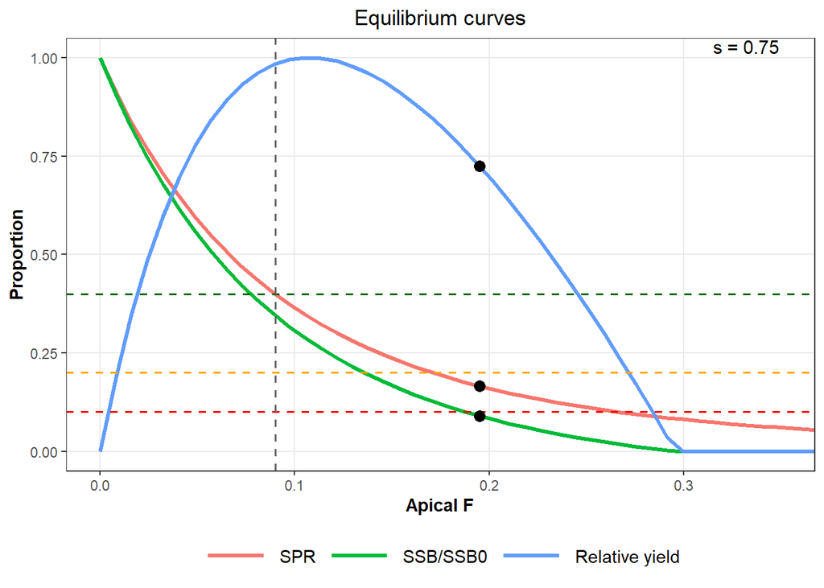

```r
plot_eqcurves(eqstk)
```

The same quantities without steepness, as per-recruit curves:

```r
prbrp <- prbrp_flicc(fit)
fmsy_flicc(prbrp, s = 0.75)
```

```
#> [1] 0.1053
```

```r
fspr_flicc(fit, spr = 35)
```

```
#> [1] 0.1045769
```

## 9.3 From SPR to relative spawning biomass

```r
round(spr2brel(c(0.2, 0.3, 0.4), s = 0.75, sprref = 40), 3)
```

```
#> [1] 0.368 0.684 1.000
```

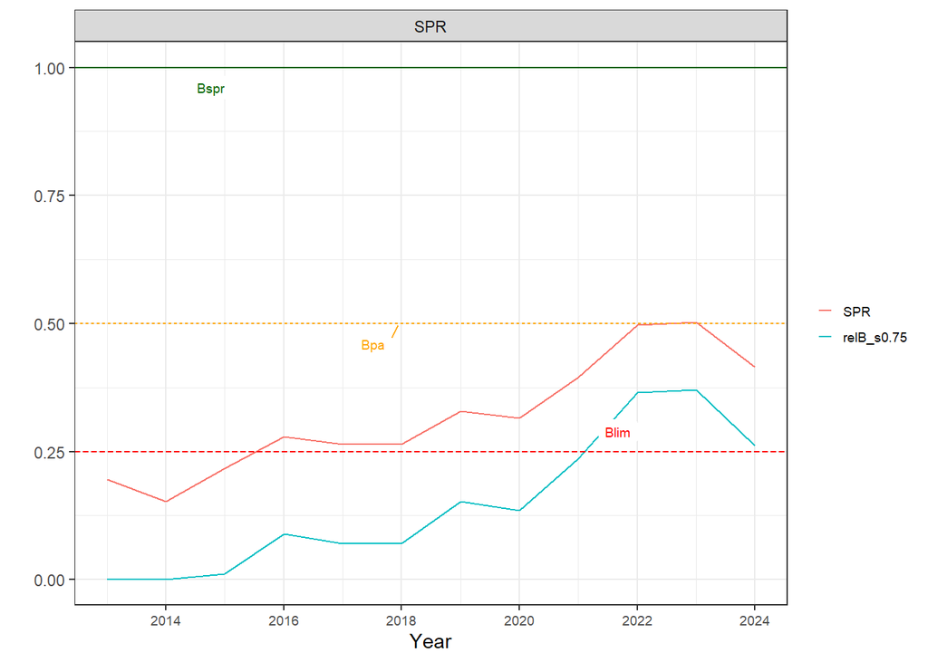

```r
plot_LBAdvice(FLStocks(SPR = flicc2FLStockR(fit, rel = TRUE),
                       relB_s0.75 = flicc2FLStockR(fit, rel = TRUE, s = 0.75)), panel = 1)
```

## 9.4 Stock status and advice plots

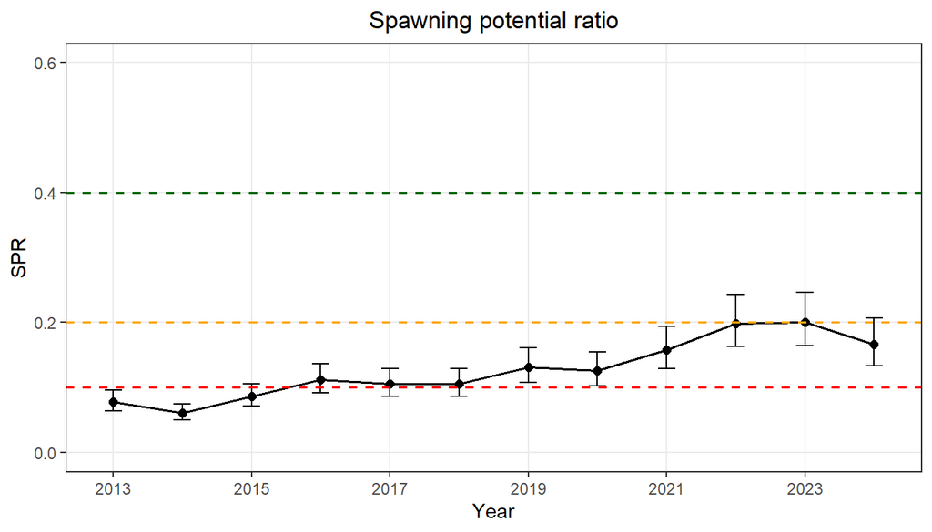

```r
plot_spr(fit, ci = TRUE)
```

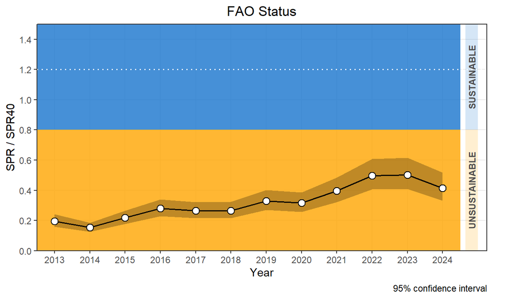

```r
plot_lbfao(fit)
```

`flicc2FLStockR()` converts the fit into an `FLStockR` object for advice plots: SPR (or $B/B_{tgt}$ with `s`) as the biomass indicator and F relative to Fspr, with reference points from the SPR target (`spr.btgt = 0.4`), `bpa` and `blim`:

```r
stk <- flicc2FLStockR(fit)
stk@refpts
```

```
#> An object of class "FLPar"
#> params
#> Fspr Bspr  Bpa Blim
#> 0.09 0.40 0.20 0.10
#> units:  NA
```

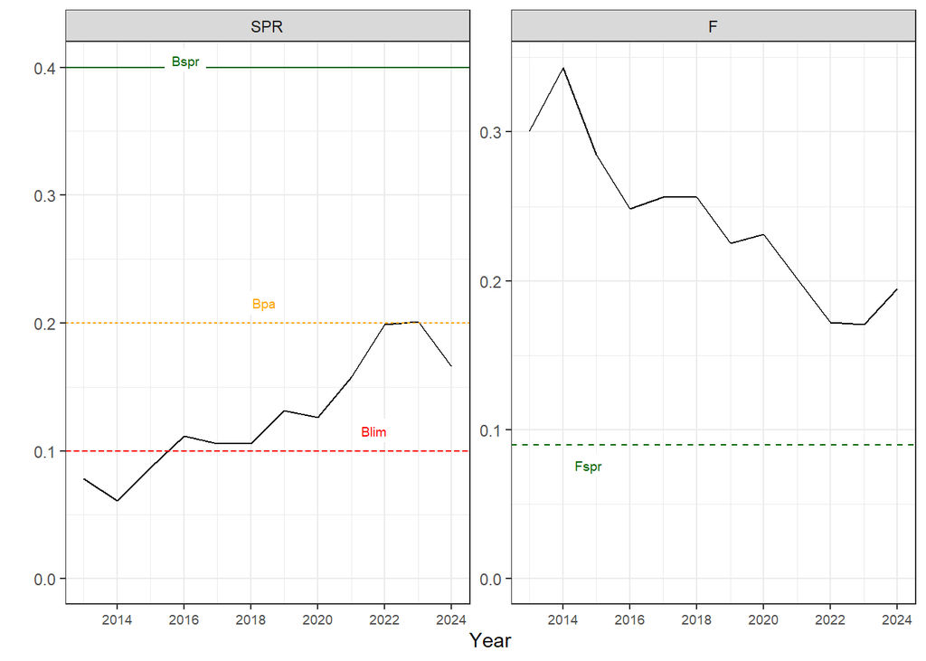

```r
plot_LBAdvice(stk)
```

With `rel = TRUE` the indicators are relative to the target (1 = at target), the usual form for advice:

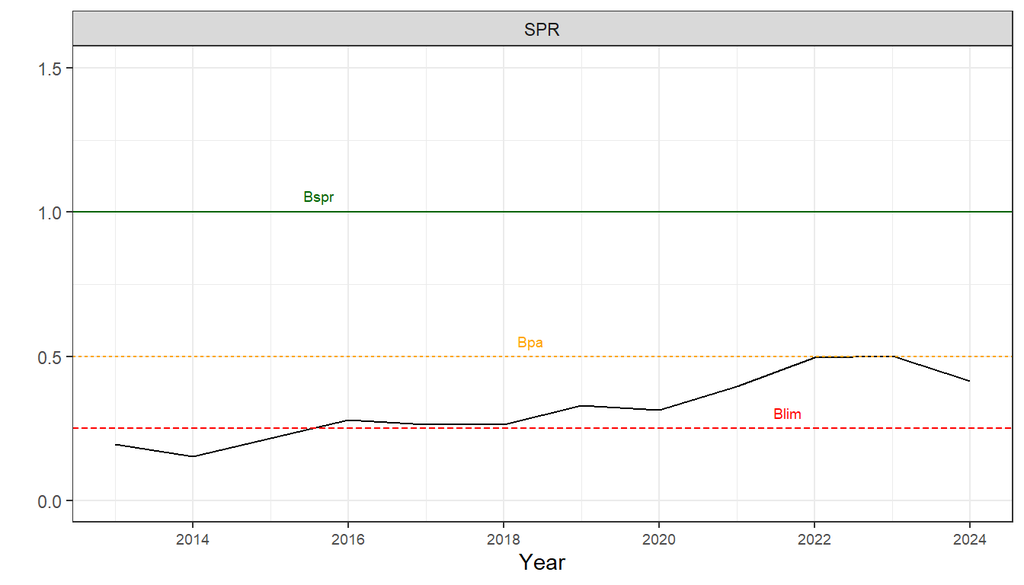

```r
stk_rel <- flicc2FLStockR(fit, rel = TRUE)
plot_LBAdvice(stk_rel, panels = 1) + ylim(0, 1.5)
```

`flicc_stklen(fit)` returns the fitted `FLStockLen` (numbers, catch and F at length by year) for further FLR workflows.

## 9.5 Status over F, selectivity and gear shares: contour plots

`contour_flicc()` computes yield per recruit and SPR over a grid, and `plot_contour_flicc()` draws one row per gear with yield on the left and spawning potential on the right. The grid can be laid out in three ways (`view`):

| `view` | x-axis | y-axis | other gears |
| --- | --- | --- | --- |
| `"fleet"` (default) | total F, F shares between gears as now | the gear’s `SL50` (logistic) or mode (dome) | F scaled with the total, selectivity as fitted |
| `"share"` | total F | the gear’s share of the total F (%) | the rest of the total F, in their current proportions |
| `"gear"` | the gear’s own F | the gear’s `SL50` or mode | current F and selectivity |

A change of selectivity shifts the gear’s curve along the length axis, keeping its shape. Yield is shown as % of its maximum over the grid (viridis colours); SPR in % on a scale anchored on the reference points: red below SPR 20%, orange to pale yellow between 20% and 40%, blue above 40%. The black lines are SPR 40% (solid) and 20% (dashed), the point is the current state, and the dotted horizontal line is the length at 50% maturity (Lmat).

The default view asks: if the whole fleet fished more or less, with the gears in their current proportions, and one gear changed its selectivity, what would yield and SPR be?

```r
cf <- contour_flicc(fit)
cf$current
```

```
#>            gear     type      loc         F       SPR       YPR    YPRrel     Fshare
#> Trawl     Trawl dsnormal 23.83475 0.2107964 0.1660614 0.1470791 0.8569229 0.92103616
#> Gillnet Gillnet logistic 30.35835 0.2107964 0.1660614 0.1470791 1.0001515 0.07896384
#>             Cshare
#> Trawl   0.94969439
#> Gillnet 0.05030561
```

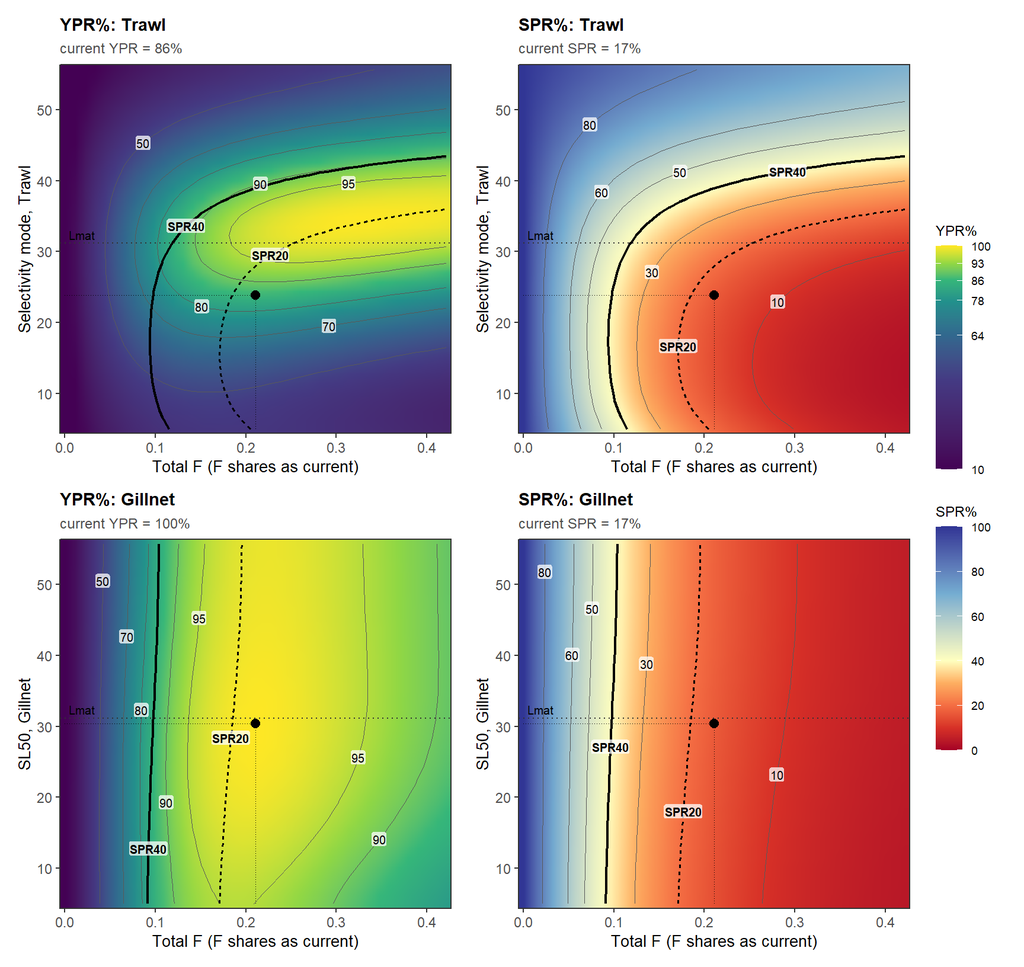

```r
plot_contour_flicc(cf)
```

The share view keeps all selectivities as fitted and asks how the split of F between gears matters. With two gears the two rows mirror each other, so one gear is enough. The subtitle gives the gear’s current share of F and of the catch; the two differ because the gears catch fish of different sizes.

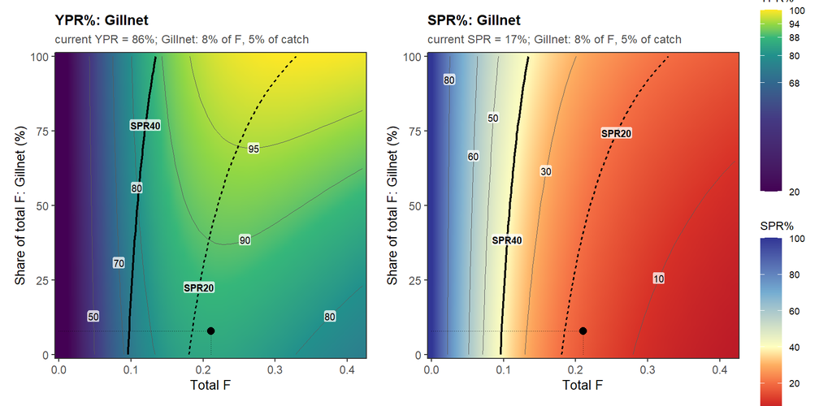

```r
cs <- contour_flicc(fit, view = "share", gear = "Gillnet")
plot_contour_flicc(cs)
```

In the `"gear"` view only one gear’s F changes; the other gears keep fishing at their current F, so at zero F of one gear the SPR reflects the other gear alone, and the catch split changes along the axis.

Per-recruit results assume constant recruitment. With a steepness `s`, the same surfaces are converted under a Beverton-Holt relationship to **SSB%** (spawning biomass in % of unfished, $B/B_0$) and **Yield%** (equilibrium yield in % of its maximum over the grid), with $R/R_0 = \frac{4s\,SPR - (1-s)}{(5s-1)\,SPR}$ and $B/B_0 = \frac{4s\,SPR - (1-s)}{5s-1}$. The black lines are then SSB 40% and 20%:

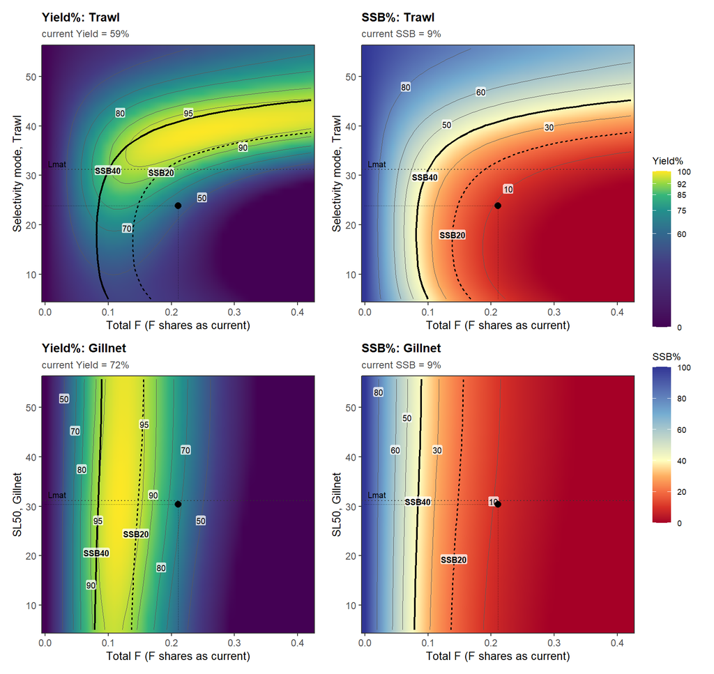

```r
plot_contour_flicc(cf, s = 0.75)
```

How to read them:

- Moving left (less F) or up (larger fish first caught) raises SPR; the yield isopleths show what that costs, or gains.
- Here the gillnet catches at `SL50` = 30.4 cm, below Lmat (31.2 cm). With all F as now, raising the gillnet `SL50` to Lmat gives an SPR of about 17% (now 17%) for a change in YPR of 0%; reaching SPR 40% at the current `SL50` by the gillnet alone needs its F cut by about more than 100%.
- Without `s` the surfaces are per-recruit results; with `s` they include the loss of recruitment at low spawning biomass, so yield falls off more steeply at high F. Both are equilibrium results at the fitted life history, a guide to direction and scale, not a forecast.

`gear =` selects gears (rows), `n` the grid resolution, `Fmax` and `Lrange` the axes, `ref` the reference levels (target, limit), and `levels`, `ylevels` the grey isopleths of the two columns.

# 10 Sensitivity runs and ensembles: a single year

Many assessments have length data for one year only. FLicc then fits that year (`years =`), and the uncertainty about the assumptions comes from **sensitivity runs**: the same data refitted with one assumption changed at a time. `fits_summary()` gives one table for a list of fits, and `ensemble_flicc()` combines them into one estimate of SPR.

The reference fit and the sensitivity runs for the last year of the alfonsino data: the gillnet with a dome (right-hand SD fixed at 0.85, 0.7 and 0.55 x Linf), CVL 0.08 and 0.12, and Linf +/- 10%. `lapply()` runs one fit per value.

**Observation model for a single year: the multinomial.** The fits use `obs_model = "mn"`. The Dirichlet-multinomial with estimated precision (`dm_theta = "saturating"`, the default) estimates how much more variable the compositions are than a multinomial sample of the same size, from the misfit that remains after the fit. With one year that is one composition per gear: the selectivity and F of each gear are fitted to that same composition, little misfit is left over, and nothing shows overdispersion. The precision then runs to its upper bound (FLicc reports this), the likelihood is flat in it, and the convergence check fails (Hessian not positive definite). Over many years the variation between years informs the precision; for one year it is not estimable. For a single year, use

- `obs_model = "mn"` with a moderate effective sample size (`lfdess()`, about 150-200 per gear, or in proportion to the number of samples, e.g. landings); raw counts of thousands of fish give intervals that are too narrow; or
- `obs_model = "dm"` with `dm_theta = "fixed"` (no precision to estimate; effective sample size about half the input); or
- with several gears in the same year, the estimated precision may work with `dm_shared = TRUE` (one precision for all gears), as there are then several compositions per precision parameter.

```r
yr <- 2024
set_ref <- list(CVL = 0.1, obs_model = "mn", FM_max = 4)

fit1 <- fiticc(lfd, stklen, sel_fun = sel_fun, catch_by_gear = cbg,
               settings = set_ref, years = yr)

rsd <- c(dome_0.85 = 47, dome_0.7 = 39, dome_0.55 = 31)       # x Linf = 55.7
dome_runs <- lapply(rsd, function(r)
  fiticc(lfd, stklen, sel_fun = c("dsnormal", "dsnormal"), catch_by_gear = cbg,
         settings = set_ref, years = yr, sel_fixed = list(Gillnet = list(rsd = r))))

cvl <- c(CVL_0.08 = 0.08, CVL_0.12 = 0.12)
cvl_runs <- lapply(cvl, function(cv)
  fiticc(lfd, stklen, sel_fun = sel_fun, catch_by_gear = cbg,
         settings = modifyList(set_ref, list(CVL = cv)), years = yr))

linf <- c(Linf_50 = 50.1, Linf_61 = 61.3)
linf_runs <- lapply(linf, function(li) {
  lh <- lhpar; lh["linf"] <- li
  fiticc(lfd, stocklen(lfd, lh, m_model = "constant"), sel_fun = sel_fun,
         catch_by_gear = cbg, settings = set_ref, years = yr)
})

runs1 <- c(list(reference = fit1), dome_runs, cvl_runs, linf_runs)
tab1 <- fits_summary(runs1)
tab1
```

```
#>         run conv   SPR   lwr   upr    FM   Fap Fspr40 F_Fspr40    AIC dAIC
#> 1 reference   ok 0.136 0.109 0.170 1.352 0.219  0.082    2.669 6260.0  0.0
#> 2 dome_0.85   ok 0.145 0.115 0.184 1.273 0.206  0.081    2.541 6266.7  6.7
#> 3  dome_0.7   ok 0.146 0.115 0.185 1.269 0.206  0.081    2.533 6266.7  6.7
#> 4 dome_0.55   ok 0.147 0.116 0.187 1.261 0.204  0.081    2.518 6266.6  6.7
#> 5  CVL_0.08   ok 0.145 0.116 0.180 1.281 0.207  0.081    2.551 6257.9 -2.1
#> 6  CVL_0.12   ok 0.125 0.094 0.167 1.467 0.238  0.083    2.850 6263.0  3.0
#> 7   Linf_50   ok 0.260 0.209 0.324 0.775 0.126  0.079    1.585 6253.6 -6.4
#> 8   Linf_61   ok 0.078 0.062 0.098 2.078 0.337  0.086    3.934 6264.6  4.6
```

**Residuals of a single year.** With one year, the residuals by length are the residual plot (a bubble plot collapses to one column). Pearson and OSA residuals of the reference fit:

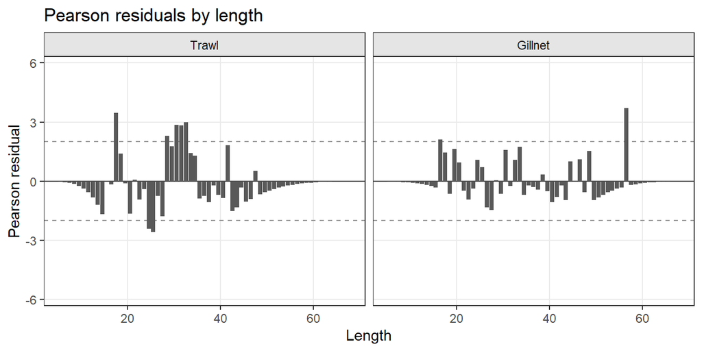

```r
plot_resid_len(fit1, type = "pearson")
```

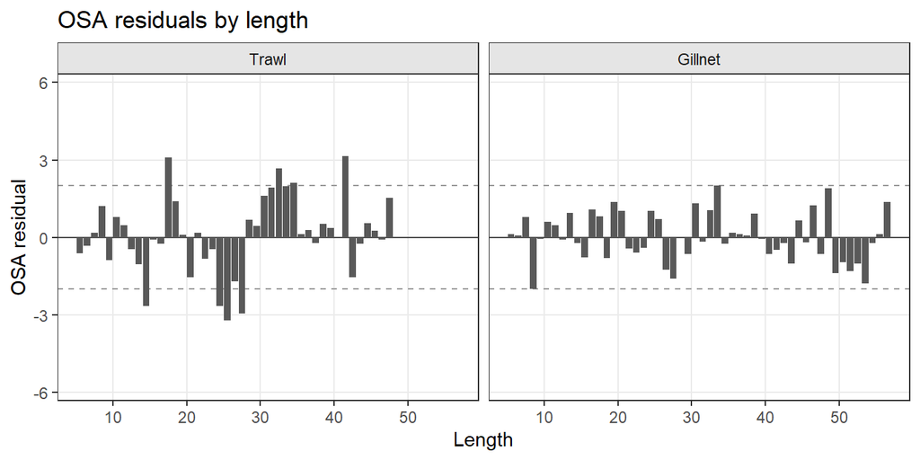

```r
plot_resid_len(fit1, type = "osa")
```

A run of residuals of one sign over several bins, in both types, means the model cannot follow the composition at those lengths. With a single year it is not possible to tell a year class from a selectivity misfit: both leave the same pattern in one composition. The multi-year fit can separate them (section *Residual diagnostics*). Residuals of a fit to one year also tend to be smaller than 1 in sd, because the parameters are estimated from the same few data.

`fits_summary()` gives, for each run, the convergence (`conv`), SPR with its confidence interval, F/M, apical F, Fspr40, current F relative to Fspr40, and AIC with dAIC relative to the first run. Use only runs with `conv = "ok"`: a run that fails is not a result (a typical failure: F slides to the lower bound of F/M and SPR to almost 1, i.e. the composition is explained without fishing). Here all runs converged. AIC is comparable between the runs because all use the same data and likelihood; a change of data (e.g. a tail cut, another ESS) breaks this.

Two ensembles of the converged runs: equal weights, and Akaike weights:

```r
ok1 <- runs1[tab1$conv == "ok"]

ens_eq  <- ensemble_flicc(ok1, weights = "equal")
ens_aic <- ensemble_flicc(ok1, weights = "aic")
ens_eq$members
```

```
#>        name weight     AIC  dAIC SPR_last se_log_last
#> 1 reference  0.125 6259.97  6.37    0.136       0.112
#> 2 dome_0.85  0.125 6266.69 13.09    0.145       0.121
#> 3  dome_0.7  0.125 6266.67 13.07    0.146       0.121
#> 4 dome_0.55  0.125 6266.63 13.03    0.147       0.123
#> 5  CVL_0.08  0.125 6257.87  4.27    0.145       0.112
#> 6  CVL_0.12  0.125 6263.02  9.42    0.125       0.146
#> 7   Linf_50  0.125 6253.60  0.00    0.260       0.112
#> 8   Linf_61  0.125 6264.58 10.98    0.078       0.116
```

```r
ens_aic$members
```

```
#>        name weight     AIC  dAIC SPR_last se_log_last
#> 1 reference  0.035 6259.97  6.37    0.136       0.112
#> 2 dome_0.85  0.001 6266.69 13.09    0.145       0.121
#> 3  dome_0.7  0.001 6266.67 13.07    0.146       0.121
#> 4 dome_0.55  0.001 6266.63 13.03    0.147       0.123
#> 5  CVL_0.08  0.100 6257.87  4.27    0.145       0.112
#> 6  CVL_0.12  0.008 6263.02  9.42    0.125       0.146
#> 7   Linf_50  0.850 6253.60  0.00    0.260       0.112
#> 8   Linf_61  0.004 6264.58 10.98    0.078       0.116
```

```r
rbind(equal = ens_eq$table, aic = ens_aic$table)[, c("year", "spr", "lwr", "upr", "sd_within", "sd_between")]
```

```
#>       year       spr        lwr       upr sd_within sd_between
#> equal 2024 0.1412501 0.07075546 0.2856443 0.1210167  0.3050354
#> aic   2024 0.2535648 0.12499338 0.3211638 0.1122987  0.2251432
```

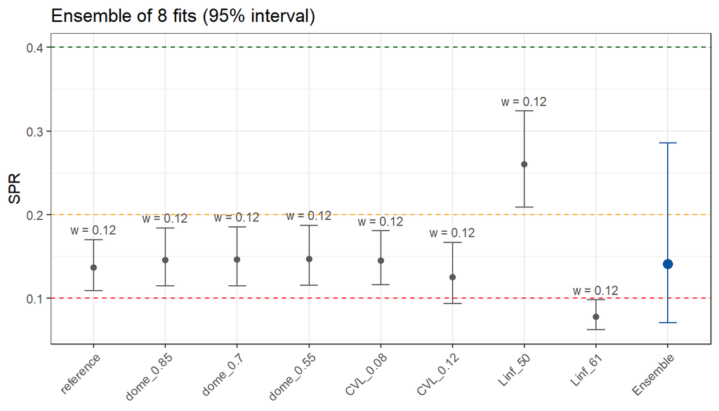

```r
plot_ensemble_flicc(ens_eq)
```

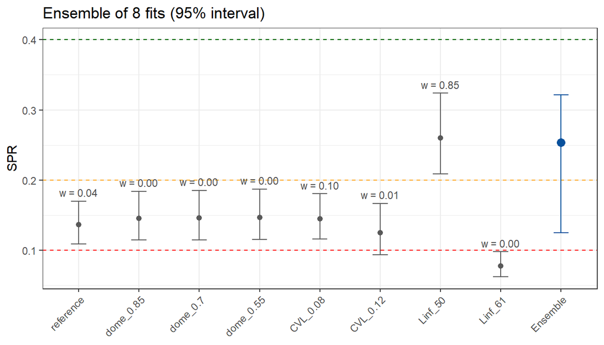

```r
plot_ensemble_flicc(ens_aic)
```

The same functions work for several years and for the dome levels of `dome_sens_flicc()` (section *Dome sensitivity*).

**One fleet with two size modes.** When catch shares by gear are uncertain, or for a quick single-fleet assessment, the gears can be pooled with `combine_lfd()` (section *Exploring selectivity shapes*) and fitted as one fleet. Its selectivity then has to describe both modes. The runs: logistic, `"binormal"`, `"bidsnormal"`, and `"bidsnormal"` with a flat second mode (`rsd2 = 1000` fixed). The pooled composition is rescaled to an ESS of 500 and shows no overdispersion beyond it, so the Dirichlet-multinomial precision is fixed (`dm_theta = "fixed"`); estimated, it runs to its upper bound and the fits fail the convergence check:

```r
fit2gear <-fiticc(lfd, stklen, sel_fun = sel_fun, catch_by_gear = cbg,
              settings = list(CVL = 0.1, obs_model = "dm", dm_theta = "saturating"))

lfd_fleet <- combine_lfd(lfd, catch_by_gear = c(0.95,0.05) ,
                         lhpar = lhpar, ess.n = 500)


stk_fleet <- stocklen(lfd_fleet, lhpar, m_model = "constant")




fleet_fun <- c(logistic = "logistic", binormal = "binormal",
               bidsnormal = "bidsnormal", bidsnormal_flat = "bidsnormal")
fleet_fix <- list(NULL, NULL, NULL, list(fleet = list(rsd2 = 1000)))

set_fleet <- modifyList(set_ref, list(dm_theta = "fixed"))

fleet_runs <- Map(function(fun, fix) {
  fiticc(lfd_fleet, stk_fleet, sel_fun = fun, catch_by_gear = 1,
         settings = set_fleet, sel_fixed = fix)
}, fleet_fun, fleet_fix)

tab_fleet <- fits_summary(c(list(ref2gear=fit2gear),fleet_runs))
tab_fleet
```

```
#>               run conv   SPR   lwr   upr    FM   Fap Fspr40 F_Fspr40     AIC     dAIC
#> 1        ref2gear   ok 0.166 0.133 0.207 1.203 0.195  0.090    2.167 74021.1      0.0
#> 2        logistic   ok 0.162 0.129 0.204 1.130 0.183  0.079    2.330 36564.7 -37456.4
#> 3        binormal   ok 0.295 0.188 0.463 0.965 0.156  0.115    1.361 36578.5 -37442.6
#> 4      bidsnormal   ok 0.380 0.218 0.662 0.776 0.126  0.119    1.060 36517.6 -37503.5
#> 5 bidsnormal_flat   ok 0.139 0.110 0.175 1.369 0.222  0.084    2.649 36527.3 -37493.9
```

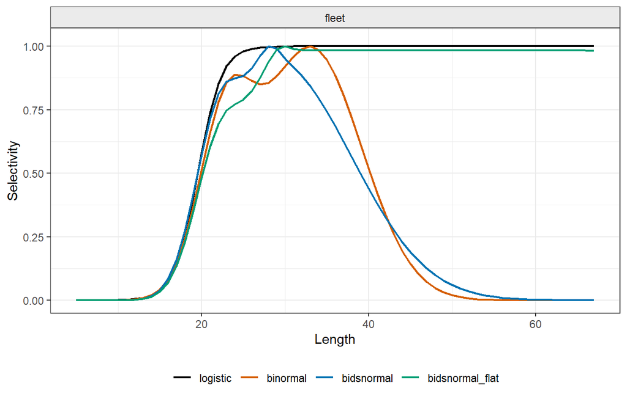

```r
plot_compare_sel(fleet_runs)
```

```r
ok_fleet   <- tab_fleet$conv == "ok"
best_fleet <- if (any(ok_fleet)) tab_fleet$run[ok_fleet][which.min(tab_fleet$AIC[ok_fleet])] else
  tab_fleet$run[which.min(tab_fleet$AIC)]
best_fleet
```

```
#> [1] "bidsnormal"
```

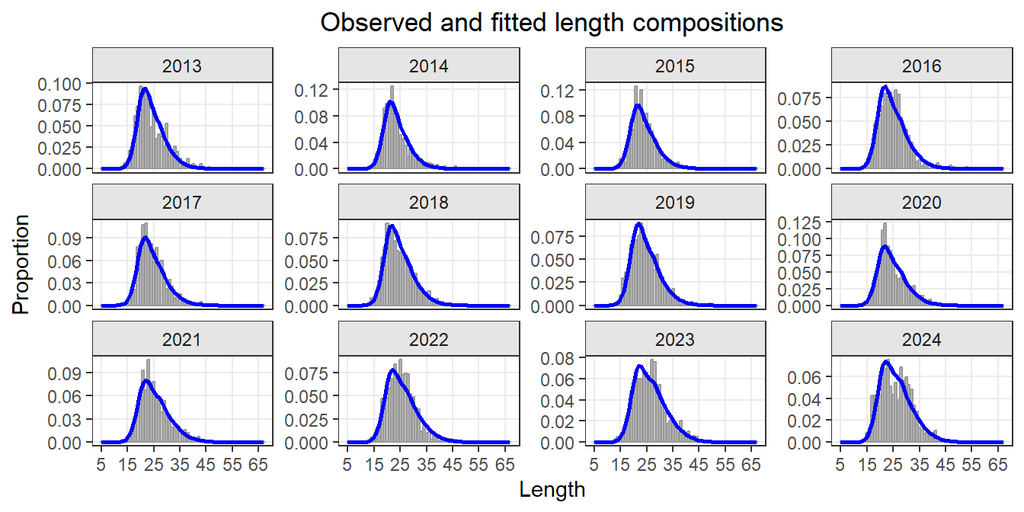

```r
plot_len(fleet_runs[[best_fleet]])
```

```r
selpars_flicc(fleet_runs$bidsnormal)
```

```
#> An object of class "FLPars"
#> [[1]]
#> An object of class "FLPar"
#> params
#> mode1   sd1 mode2  lsd2  rsd2     h
#> 22.80  3.00 29.53  3.01  8.97  1.23
#> units:  cm
#>
#> Slot "names":
#> [1] "fleet"
#>
#> Slot "desc":
#> character(0)
#>
#> Slot "lock":
#> [1] FALSE
```

```r
selpars_flicc(fleet_runs$bidsnormal_flat)
```

```
#> An object of class "FLPars"
#> [[1]]
#> An object of class "FLPar"
#> params
#>   mode1     sd1   mode2    lsd2    rsd2       h
#>   22.61    2.96   30.57    3.97 1000.00    1.72
#> units:  cm
#>
#> Slot "names":
#> [1] "fleet"
#>
#> Slot "desc":
#> character(0)
#>
#> Slot "lock":
#> [1] FALSE
```

# 11 Length-based indicators

Length-based indicators (LBIs) summarise each length composition in a few numbers that can be compared with reference levels or followed over time. The empirical indicators need no model fit and only Linf and L50 (for some, also M/k), so they can be computed at the start of an assessment and by analysts without modelling experience. The model-based indicators (`LBIspr`, `LBImean`) use the fitted selectivity and growth.

## 11.1 Empirical indicators (no model)

`lbi_flicc()` computes, for each gear and year, the indicators of ICES WKLIFE and of Froese (2004), the reference lengths, and a Beverton-Holt estimate of total mortality from the mean length:

| Indicator | Definition | Reference (green) | Limit (red below) | Property |
| --- | --- | --- | --- | --- |
| Lc/L50, L25/L50 | length at half the modal abundance; 25th percentile | 1 | 0.75 | conservation of immatures |
| Lmax5/Linf, L95/Linf | mean of the largest 5%; 95th percentile | 0.8 | 0.7 | conservation of large fish |
| Pmega | proportion above 1.1 Lopt | 0.3 | 0.15 | conservation of large fish |
| LmaxY/Lopt, Lmean/Lopt | class of maximum catch biomass; mean length above Lc | 0.9 | 0.75 | optimal yield |
| Lmean/LFM | LFM = 0.75 Lc + 0.25 Linf, the mean length at F = M | 1 | 0.9 | MSY proxy |
| Pobj (Cope-Punt) | Pmat + Popt + Pmega, with a decision tree | see below | – | spawning biomass vs 0.4 B0 |

The traffic light has three colours: green at or above the ICES reference level, orange between the limit and the reference level, red below the limit. The limits are pragmatic choices (10-25% below the reference level, half of it for Pmega) that separate a clear departure from a marginal one; they can be changed with `limits`, e.g. `limits = c("Lmean/LFM" = 0.85)`.

with $L_{opt} = 2/3\,L_\infty$ (or $L_\infty\,3/(3 + M/k)$ with `Lopt = "mk"`), and the proportions of mature fish (`Pmat`), of fish around Lopt (`Popt`) and their sum `Pobj`. Cope and Punt (2009) use `Pobj` to identify the selectivity pattern of the fishery (below 1: mainly small and immature fish; between 1 and 2: selection close to the maturity ogive; 2: only mature fish of optimal size and larger), and then `Pmat` or `Popt` to judge whether spawning biomass is at or above the target of 0.4 B0 (`cp_selectivity`, `cp_test`, `cp_status`). A fishery that takes only fish of optimal size gives no information on status. `pool = TRUE` adds the gears pooled into one composition, as gear `"pooled"`: the length frequency of each gear is raised to catch numbers with its relative catch (`catch_by_gear`, in weight by default, `catch_units = "numbers"` otherwise) and the gears are summed (`combine_lfd()`). Each gear then contributes in proportion to its catch, not to how many fish were measured. For a fit, the fit’s catch by gear is used by default:

```r
lbi <- lbi_flicc(lfd, lhpar, pool = TRUE, catch_by_gear = c(Trawl = 0.95, Gillnet = 0.05))
lbi$values[lbi$values$year == 2024, c("gear", "Lc", "Lmean", "LFM", "L95", "Lmax5", "Pmat", "Pmega", "Z")]
```

```
#>       gear   Lc    Lmean   LFM      L95    Lmax5      Pmat      Pmega         Z
#> 12   Trawl 17.5 26.43526 27.05 35.71429 39.10000 0.2150000 0.01333333 0.2481307
#> 24 Gillnet 28.5 34.50847 35.30 43.33333 46.30000 0.6775000 0.08250000 0.2604792
#> 36  pooled 17.5 26.61855 27.05 36.20543 39.58779 0.2268882 0.01511120 0.2418781
```

```r
lbi$values[lbi$values$year == 2024, c("gear", "Pobj", "cp_selectivity", "cp_test", "cp_status")]
```

```
#>       gear      Pobj              cp_selectivity     cp_test   cp_status
#> 12   Trawl 0.3316667 small and optimal-size fish Pmat > 0.31 SB < target
#> 24 Gillnet 1.1750000              maturity ogive Pmat > 0.92 SB < target
#> 36  pooled 0.3533438 small and optimal-size fish Pmat > 0.31 SB < target
```

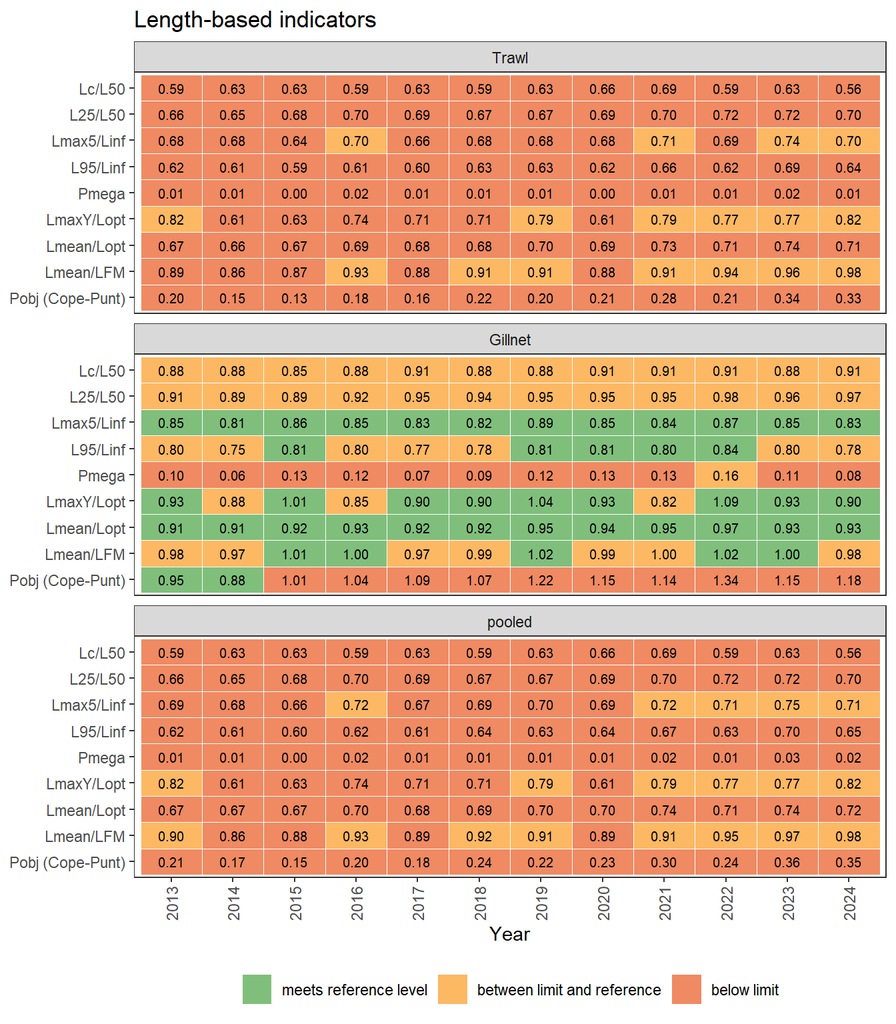

```r
plot_lbi(lbi)
```

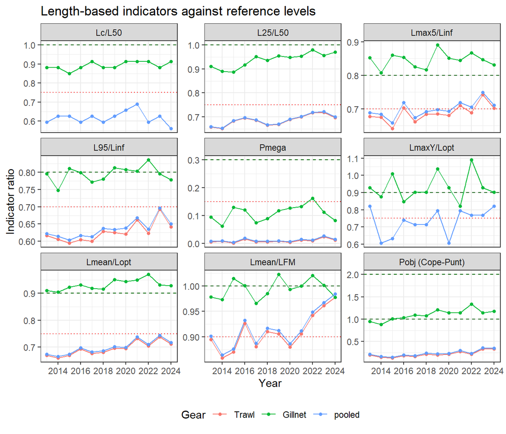

```r
plot_lbi(lbi, type = "trend")
```

How to read them:

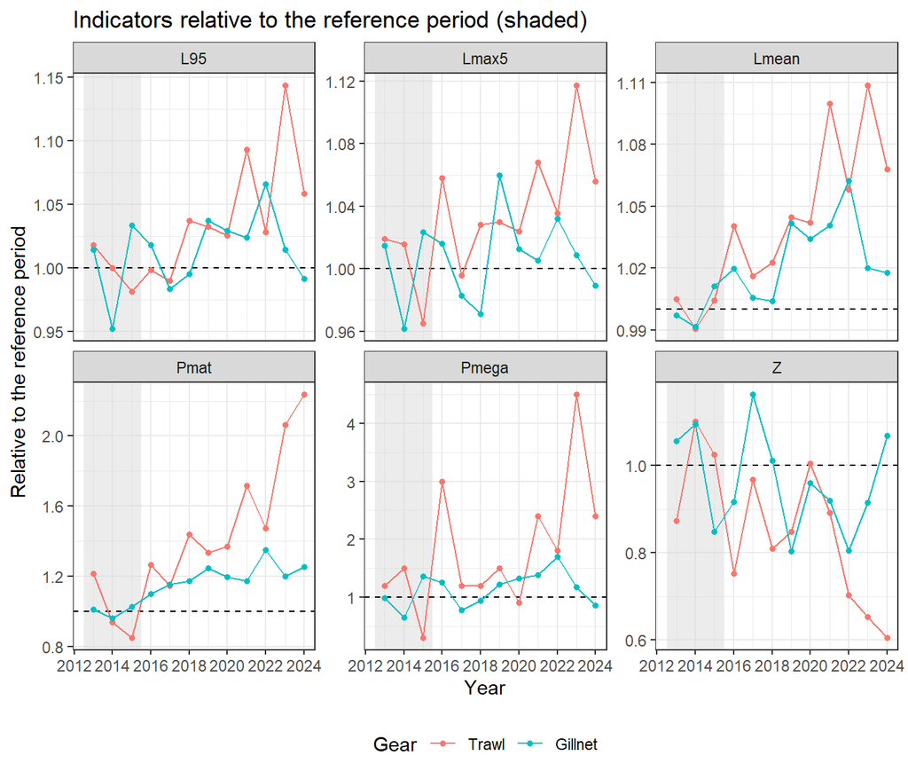

```r
lbi_ref <- lbi_flicc(lfd, lhpar, ref_years = 2013:2015)
plot_lbi(lbi_ref, type = "relative")
```

Here the large-fish indicators and the proportion mature have increased since 2013-2015 and the mean-length estimate of Z has decreased: the size structure has improved over the period, in line with the decrease in F estimated by the model.

## 11.2 LBIspr

For each gear, `LBIspr()` compares the observed proportion of large fish with the proportion expected at the reference $F_{\mathrm{SPR}x}$:

1. Equilibrium numbers-at-length at $F_{\mathrm{SPR}x}$, $N^{ref}(L)$, and the reference catch composition of gear $g$, $v_g(L) = N^{ref}(L) S_g(L)$ (retained bins only, i.e. below the tail cut).
2. Threshold length $L^*_g$: the length at which the cumulative $v_g$ reaches the fraction `thresh` (default 0.75) of its total.
3. Reference proportion above the threshold, $P^{ref}_g = \sum_{L \ge L^*_g} v_g(L) / \sum_L v_g(L)$ (about $1 -$ `thresh`).
4. Observed proportion in year $y$, $P^{obs}_{g,y} = \sum_{L \ge L^*_g} y_{g,y,L} / \sum_L y_{g,y,L}$.
5. Indicator $\mathrm{LBI}_{g,y} = P^{obs}_{g,y}/P^{ref}_g$.

$\mathrm{LBI} = 1$: as many large fish as at the target; $< 1$: fewer, i.e. F above $F_{\mathrm{SPR}x}$. The threshold lengths are returned as `attr(, "Lref")`.

```r
lbi <- LBIspr(fit, spr = 40, thresh = 0.75)
attr(lbi, "Lref")
```

```
#>   Trawl Gillnet
#>      30      39
```

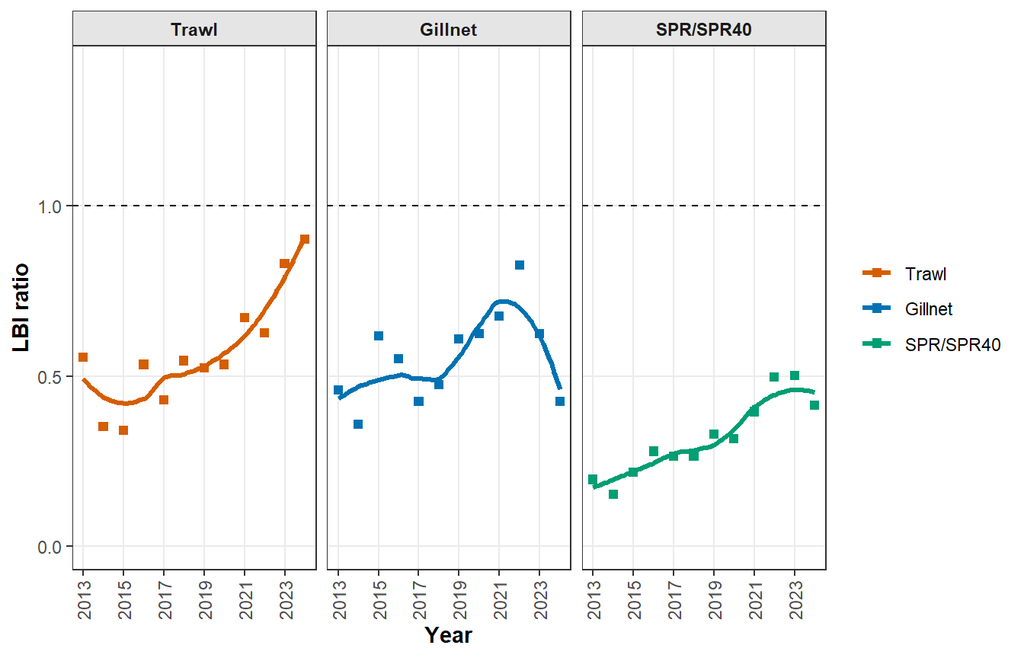

```r
plot_LBIspr(fit, thresh = 0.75)
```

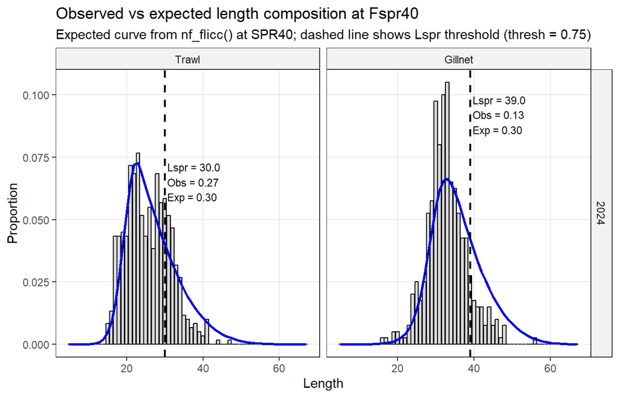

```r
plot_LBIp(fit, year = 2024)
```

## 11.3 LBImean

`LBImean()` is the model-based analogue of the ICES mean-length indicator $\bar L/L_{F=M}$: the reference mean length (above `lc`, default the gear’s 50% selectivity length) is computed from the fitted model at $F = M$ (`ref = "FM"`) or at $F_{\mathrm{SPR}x}$ (`ref = "spr"`), using the fitted growth variability and gear selectivity, including domes.

```r
LBImean(fit, ref = "FM")
```

[output not shown]

## 11.4 Indicators and the tail cut

Both indicators use the fit’s tail cut by default (`tail_cut = NULL`), so the indicator and the likelihood use the same bins; `tail_cut = FALSE` uses all bins.

## 11.5 Check 10: indicators against status

| **Look for** | LBIspr and SPR/SPR40 telling the same story; similar indicators across gears. |
| --- | --- |
| **Red flags** | Gears disagreeing strongly (selectivity misfit or sampling); indicator noise much larger than the SPR trend. |
| **Action** | Use the more informative gear; pool gears (`pool` in `flicc.sa()`); smooth in the harvest control rule. |

# Part II: Technical options

# 12 Effective sample size and observation models

## 12.1 How the sample size enters the likelihood

For gear $g$ in year $y$, with observed counts $y_{g,y,l}$, total $n_{g,y} = \sum_l y_{g,y,l}$ and predicted proportions $\pi_{g,y,l}$:

- **Multinomial** (`obs_model = "mn"`): $-\log L = -\sum_l y_{g,y,l} \log \pi_{g,y,l}$. The weight of a composition is proportional to $n_{g,y}$.
- **Negative binomial** (`"nb"`): counts with mean $n_{g,y}\pi_{g,y,l}$ and overdispersion $\phi$ (estimated), variance $\mu + \mu^2/\phi$.
- **Dirichlet-multinomial** (`"dm"`): the compositions are drawn from a Dirichlet with mean $\pi_{g,y}$ and precision $\alpha_0$; in FLicc $\alpha_0 = n_{g,y}$. The variance of the proportions is inflated by $(n + \alpha_0)/(1 + \alpha_0) \approx 2$, so a DM fit at sample size $n$ carries about the information of a multinomial with $n/2$. Its log-gamma form also penalises single-bin misfits less than the multinomial, which makes it more robust with messy real data.

`lfdess(lfd, ess.g)` rescales each gear-year to the given effective sample size (ESS), keeping the proportions; empty gear-years stay empty.

## 12.2 Why very large sample sizes do harm

Measured fish are not independent: fish from one haul or trip share its length structure. Raw counts (often thousands) therefore overstate the information by an order of magnitude. With an overstated sample size:

- the likelihood is dominated by small structural misfits (growth model, binning, selectivity shape) rather than the signal, so estimates and their standard errors are overconfident;
- log-likelihood differences between alternative assumptions become huge, so AIC weights across an ensemble collapse onto a few draws and likelihood profiles become jagged or multimodal;
- any discrete effect (a fish entering or leaving the range of the largest growth group) is multiplied by $n$.

## 12.3 Choosing the effective sample size

With the default likelihood (Dirichlet-multinomial with estimated precision, next section) the data choose their own weight: give it the **raw counts or an ESS of at least 500** per gear-year, not a reduced ESS. FLicc prints a message when the median sample size is below 500.

The choice of ESS matters for the likelihoods with a weight set by the input, the multinomial (as LBSPR) and the Dirichlet-multinomial with fixed precision (`dm_theta = "fixed"`, as LBB). For these, ESS of about 150-200 per gear-year has given the most stable assessments and ensemble profiles, and 1000 or more behaved poorly in Monte-Carlo profiling:

- Base ESS on the number of independent sampling units (trips, hauls, vessels) where known, e.g. a few fish-equivalents per unit; otherwise start at 150-200 per gear-year and test 100 and 300.
- Use the same ESS for gears of similar sampling quality; reduce it for gears with few trips.
- The fixed Dirichlet-multinomial halves the nominal ESS.
- Never fit raw counts of several thousand fish per year without rescaling.

The demonstration below shows why the input matters for these likelihoods: it fits the alfonsino data at five effective sample sizes (`ess_values`), once with the multinomial and once with the fixed Dirichlet-multinomial, and once more with the raw counts. `lfdess()` rescales the compositions to the given ESS; `Map()` runs one fit per value. For each fit the table shows the last-year SPR (`sprcur_flicc()`), its standard error on the log scale (from `spr_ci_flicc()`) and the largest absolute gradient at the optimum.

```r
sel_fun <- c("dsnormal", "logistic")
cbg <- c(0.95, 0.05)
stklen <- stocklen(lfd, lhpar, m_model = "constant")

ess_values <- c(50, 100, 200, 500, 1000)

# multinomial: one fit per ESS
fits_mn <- Map(function(ess) {
  fiticc(lfdess(lfd, ess.g = ess), stklen, sel_fun = sel_fun, catch_by_gear = cbg,
         settings = list(CVL = 0.1, obs_model = "mn"))
}, ess_values)
names(fits_mn) <- paste0("mn_", ess_values)

# Dirichlet-multinomial with fixed precision: one fit per ESS
fits_dm <- Map(function(ess) {
  fiticc(lfdess(lfd, ess.g = ess), stklen, sel_fun = sel_fun, catch_by_gear = cbg,
         settings = list(CVL = 0.1, obs_model = "dm", dm_theta = "fixed"))
}, ess_values)
names(fits_dm) <- paste0("dm_", ess_values)

# raw counts (no rescaling)
fit_raw_mn <- fiticc(lfd, stklen, sel_fun = sel_fun, catch_by_gear = cbg,
                     settings = list(CVL = 0.1, obs_model = "mn"))
fit_raw_dm <- fiticc(lfd, stklen, sel_fun = sel_fun, catch_by_gear = cbg,
                     settings = list(CVL = 0.1, obs_model = "dm", dm_theta = "fixed"))
raw_n <- round(mean(quantSums(lfd[["Trawl"]])))   # fish per year, trawl

fits_mn <- c(fits_mn, raw = list(fit_raw_mn))
fits_dm <- c(fits_dm, raw = list(fit_raw_dm))

# standard error of log SPR in the last year
se_logspr <- function(fit) tail(spr_ci_flicc(fit)$se_log, 1)
ess_table <- data.frame(
  ESS        = c(ess_values, paste0("raw (~", raw_n, ")")),
  SPR_mn     = round(sapply(fits_mn, sprcur_flicc), 3),
  SPR_dm     = round(sapply(fits_dm, sprcur_flicc), 3),
  se_mn      = round(sapply(fits_mn, se_logspr), 3),
  se_dm      = round(sapply(fits_dm, se_logspr), 3),
  maxgrad_dm = signif(sapply(fits_dm, function(fit) fit$max_gradient), 2),
  row.names  = NULL)
ess_table
```

```
#>          ESS SPR_mn SPR_dm se_mn se_dm maxgrad_dm
#> 1         50  0.173  0.358 0.238 0.236    2.7e-06
#> 2        100  0.171  0.258 0.184 0.205    5.8e-06
#> 3        200  0.167  0.201 0.139 0.167    5.3e-06
#> 4        500  0.163  0.164 0.092 0.118    3.0e-05
#> 5       1000  0.161  0.150 0.066 0.088    2.5e-05
#> 6 raw (~600)  0.174  0.173 0.095 0.123    1.8e-05
```

The alfonsino example has about 600 fish per gear-year, so its raw counts are moderate; with the thousands of fish per year common in market sampling the effects above are much stronger, also for the AIC weights of a Monte-Carlo ensemble.

SPR with 95% intervals for the Dirichlet-multinomial at ESS 50, 200 and 1000 and for the raw counts:

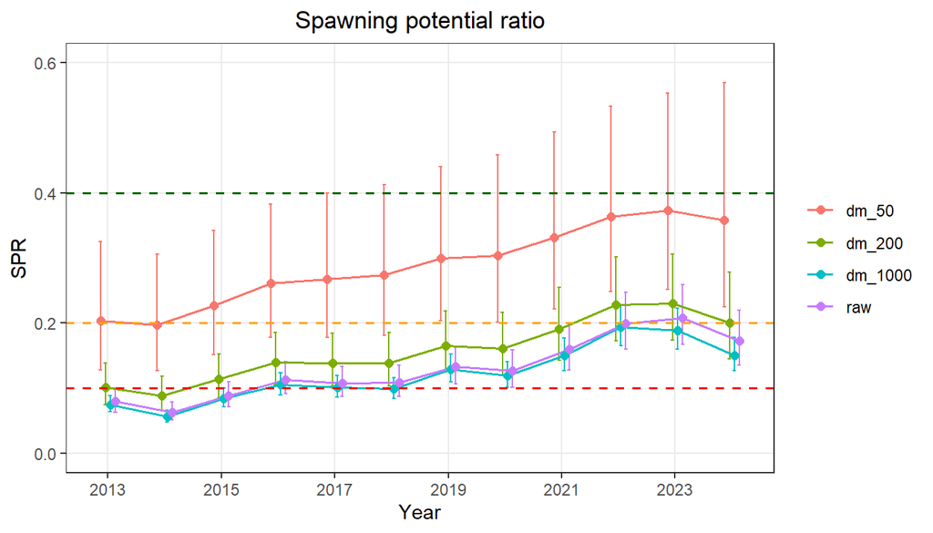

```r
plot_spr(fits_dm[c("dm_50", "dm_200", "dm_1000", "raw")], ci = TRUE)
```

## 12.4 Letting the data choose their weight: estimated Dirichlet-multinomial precision

With `dm_theta = "fixed"` the Dirichlet precision is $\alpha_0 = n$, so the effective sample size the likelihood uses is
$$n_{eff} = \frac{n\,(1 + \alpha_0)}{n + \alpha_0} = \frac{1 + n}{2} \approx \frac{n}{2},$$
proportional to the input ESS, as shown above. FLicc can instead estimate the precision by gear (Thorson et al. 2017):

| `dm_theta` | $\alpha_0$ | $n_{eff}$ | as the input ESS grows |
| --- | --- | --- | --- |
| `"fixed"` | $n$ | $\approx n/2$ | grows without limit |
| `"linear"` | $\theta n$, $\theta$ estimated | $(1 + \theta n)/(1 + \theta)$ | grows, at a rate set by $\theta$ |
| `"saturating"` (default) | $\beta$, estimated | $n(1 + \beta)/(n + \beta)$ | levels off at $\beta + 1$ |

With `"saturating"`, once the input sample size is well above $\beta$ the effective sample size no longer depends on it: the data estimate how much each composition can count. The input matters only if it is *below* what the data support. Then there is no overdispersion to estimate, $\beta$ runs towards infinity, and the model becomes a multinomial at the input sample size; a weak prior (`dm_prior_sd = 1`, centred close to a multinomial) keeps it finite, and FLicc reports the precision as being at its bound. For this reason, **with an estimated precision use the raw counts or an ESS of at least 500**, so that the data, not the input, set the weight.

The fits below use the saturating Dirichlet-multinomial at ESS 500 and 1000 and on the raw counts; `neff_flicc()` reports the estimated effective sample size by gear and year.

```r
dm_inputs <- list(ESS_500 = lfdess(lfd, ess.g = 500), ESS_1000 = lfdess(lfd, ess.g = 1000), raw = lfd)
fits_dms <- Map(function(d) {
  fiticc(d, stklen, sel_fun = sel_fun, catch_by_gear = cbg,
         settings = list(CVL = 0.1, obs_model = "dm", dm_theta = "saturating"))
}, dm_inputs)

neff_gear <- function(fit, g) { ne <- neff_flicc(fit); round(mean(ne$neff[ne$gear == g])) }
dm_table <- data.frame(
  input        = names(fits_dms),
  SPR_last     = round(sapply(fits_dms, sprcur_flicc), 3),
  se_log       = round(sapply(fits_dms, se_logspr), 3),
  neff_Trawl   = sapply(fits_dms, neff_gear, g = "Trawl"),
  neff_Gillnet = sapply(fits_dms, neff_gear, g = "Gillnet"),
  row.names = NULL)
dm_table
```

```
#>      input SPR_last se_log neff_Trawl neff_Gillnet
#> 1  ESS_500    0.165  0.112        351          275
#> 2 ESS_1000    0.156  0.111        314          248
#> 3      raw    0.166  0.113        342          284
```

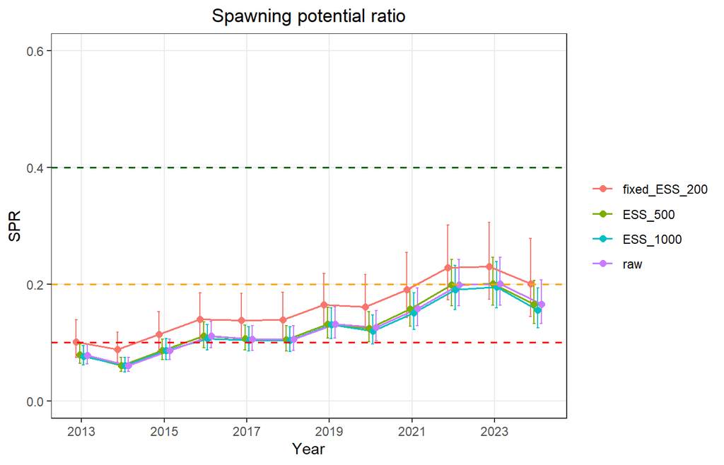

```r
plot_spr(c(fixed_ESS_200 = list(fits_dm$dm_200), fits_dms), ci = TRUE)
```

The last-year SPR is 0.156 to 0.166 whatever the input, against 0.15 to 0.358 for the fixed precision over ESS 50 to 1000. The compositions support an effective sample size of about 342 (trawl) and 284 (gillnet) fish per year; the fixed precision at ESS 200 used about 100.

The estimated precision describes the noise *within* compositions. Year classes that shift whole compositions between years are a different kind of misfit, which the residual diagnostics (section *Residual diagnostics*) show and the precision does not absorb.

# 13 Fishing mortality over time

Log F by gear follows a random walk,
$$\log F_{g,y} = \log F_{g,y-1} + \varepsilon_{g,y}, \qquad \varepsilon_{g,y} \sim N(0, \sigma_F^2).$$
With selectivity $S_g(L)$ shared by all years, the model is fitted to all compositions at once; the objective is
$$-\log L = -\sum_{y} \log L_y\!\left(F_{\cdot,y}, S\right)
- \sum_{g,y>1} \log \phi\!\left(\log F_{g,y} - \log F_{g,y-1};\, 0, \sigma_F\right).$$
Compared with fitting each year on its own (as LBSPR does), this has four advantages:

- **Selectivity from all years.** The left limb of the compositions is informed by every year, so selectivity is better determined and does not absorb year-to-year sampling noise.
- **Borrowing strength.** A year with few fish is fitted close to its neighbours instead of producing an extreme F.
- **Missing years.** A year without data of a gear still gets an F, bridged by the random walk (section *Missing data*).
- **Separation of signal and noise.** $\sigma_F$ sets how much of the year-to-year change in the compositions is read as a change in F.

The price is smoothing: with small $\sigma_F$ a real change in F is spread over several years (section *Lag under changing F*). The options below differ in how $\sigma_F$ is treated.

The four options for $\sigma_F$ are fitted below to the same data (raw counts, Dirichlet-multinomial with estimated precision). Only the F settings differ, so each option has its own `settings` list; `Map()` fits them in turn.

```r
f_settings <- list(
  fixed_0.3 = list(CVL = 0.1, obs_model = "dm", dm_theta = "saturating", sigmaF = 0.3),                       # default
  prior     = list(CVL = 0.1, obs_model = "dm", dm_theta = "saturating", prior_sigmaF = c(log(0.5), 0.3, 1)), # penalised
  F_re      = list(CVL = 0.1, obs_model = "dm", dm_theta = "saturating", F_re = TRUE),                        # random effects
  no_RW     = list(CVL = 0.1, obs_model = "dm", dm_theta = "saturating", prior_sigmaF = FALSE))               # no random walk

fits_F <- Map(function(set) {
  fiticc(lfd, stklen, sel_fun = sel_fun, catch_by_gear = cbg, settings = set)
}, f_settings)

data.frame(option   = names(fits_F),
           sigmaF   = round(sapply(fits_F, sigmaF_flicc), 3),
           SPR_last = round(sapply(fits_F, sprcur_flicc), 3),
           se_log   = round(sapply(fits_F, se_logspr), 3),
           row.names = NULL)
```

```
#>      option sigmaF SPR_last se_log
#> 1 fixed_0.3  0.300    0.166  0.113
#> 2     prior  0.172    0.171  0.104
#> 3      F_re  0.135    0.174  0.099
#> 4     no_RW     NA    0.159  0.121
```

`sigmaF_flicc()` returns the fixed or estimated $\sigma_F$ (NA without a random walk). The SPR trajectories with 95% intervals, and the apical F by year (`report$Fap`):

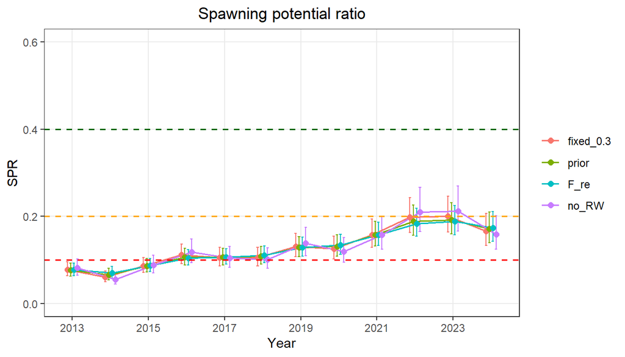

```r
plot_spr(fits_F, ci = TRUE)
```

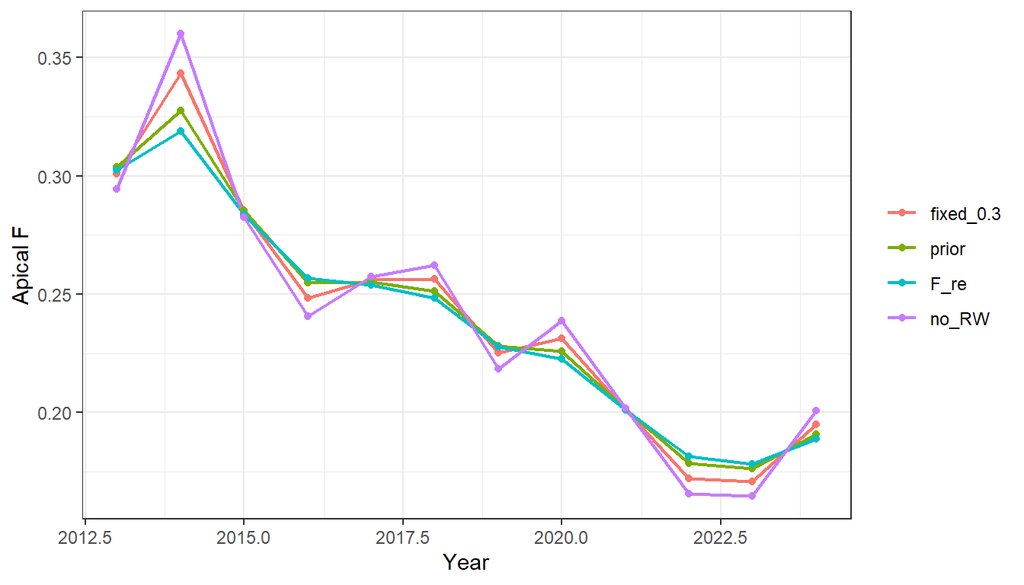

```r
F_by_option <- FLQuants(fixed_0.3 = fits_F$fixed_0.3$report$Fap,
                        prior     = fits_F$prior$report$Fap,
                        F_re      = fits_F$F_re$report$Fap,
                        no_RW     = fits_F$no_RW$report$Fap)
ggplot(F_by_option, aes(year, data, colour = qname)) +
  geom_line(linewidth = 0.8) + geom_point(size = 1.5) +
  labs(x = "Year", y = "Apical F", colour = NULL) + theme_bw()
```

The estimated $\sigma_F$ of the penalised and random-effects options is much smaller than 0.3, so their F trajectories are smoother; without a random walk F follows each year’s composition. To see what $\sigma_F$ does, the next runs fix it at a range of values (`sigmaF_values`):

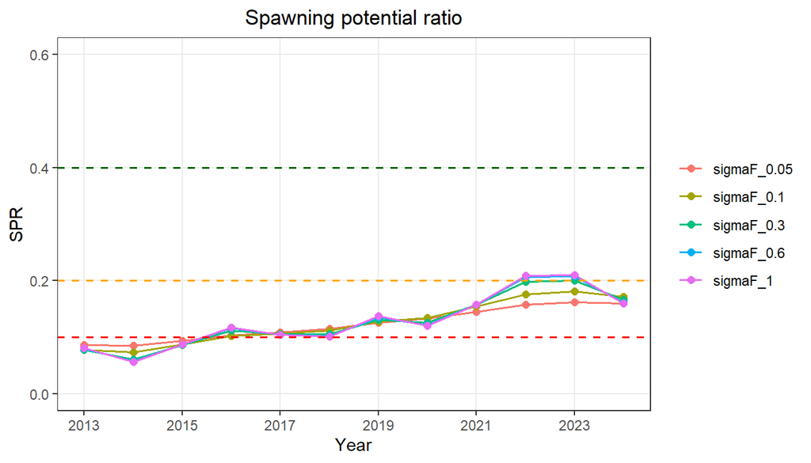

```r
sigmaF_values <- c(0.05, 0.1, 0.3, 0.6, 1)

fits_sigmaF <- Map(function(sF) {
  fiticc(lfd, stklen, sel_fun = sel_fun, catch_by_gear = cbg,
         settings = list(CVL = 0.1, obs_model = "dm", dm_theta = "saturating", sigmaF = sF), se = FALSE)
}, sigmaF_values)
names(fits_sigmaF) <- paste0("sigmaF_", sigmaF_values)

plot_spr(fits_sigmaF)
```

```r
data.frame(sigmaF   = sigmaF_values,
           SPR_last = round(sapply(fits_sigmaF, sprcur_flicc), 3),
           neg_logL = round(sapply(fits_sigmaF, function(fit) fit$opt$objective), 1))
```

```
#>             sigmaF SPR_last neg_logL
#> sigmaF_0.05   0.05    0.160  36964.8
#> sigmaF_0.1    0.10    0.172  36966.7
#> sigmaF_0.3    0.30    0.166  36979.6
#> sigmaF_0.6    0.60    0.161  36991.6
#> sigmaF_1      1.00    0.160  37002.0
```

Small values force F (and SPR) towards a flat line; from about 0.3 upward the trajectories change little. The objective (`neg_logL`) includes the random-walk penalty, which is why it cannot be used to choose $\sigma_F$ directly: it always favours the smallest value that the compositions tolerate.

## 13.1 Default: sigmaF fixed

`sigmaF = 0.3` (the default) fixes the year-to-year standard deviation of log F, roughly a 30% typical annual change. It is fast, cannot collapse, and the simulations showed that it removes most of the smoothing lag (next section). Change it where fleet dynamics are known to be smoother (0.2) or more variable (0.5).

## 13.2 Estimating sigmaF with a prior (penalised)

With `prior_sigmaF = c(mu, sd, 1)`, $\sigma_F$ is a fixed-effect parameter and the objective is
$$-\log L = -\log L_{data} - \sum_{g,y} \log \phi\left(\log F_{g,y} - \log F_{g,y-1};\, 0, \sigma_F\right)
- \log \phi\left(\log \sigma_F;\, \mu, sd\right).$$
Each random-walk term contributes $-\log \sigma_F$, so the joint maximum favours small $\sigma_F$ with flat F whenever the data do not resist: the estimate is pulled down (here 0.172), and only the prior keeps it away from 0. Without a prior (`prior_sigmaF = c(NA, NA, 1)`) it collapses; FLicc warns.

## 13.3 F as random effects (`F_re = TRUE`)

The log F are integrated out,
$$L(\theta) = \int L_{data}(\theta, \mathbf F)\, p(\mathbf F \mid \sigma_F)\, d\mathbf F,$$
by the Laplace approximation (TMB): for each value of the other parameters $\theta$ (selectivity, $\sigma_F$), the F path is optimised and the curvature around it enters the marginal likelihood. Consequences:

- $\sigma_F$ is estimated from the marginal likelihood, which properly accounts for the uncertainty of the F path (here 0.135). It can still go to small values when the compositions carry little year-to-year information; a weak prior `c(log(0.3), 0.5, 1)` is used unless another is given.
- Standard errors (e.g. of log SPR) include the uncertainty of the F process.
- Fitting is slower:

```r
system.time(fiticc(lfd, stklen, sel_fun = sel_fun, catch_by_gear = cbg, settings = f_settings$fixed_0.3))
```

```
#>    user  system elapsed
#>    0.14    0.00    1.52
```

```r
system.time(fiticc(lfd, stklen, sel_fun = sel_fun, catch_by_gear = cbg, settings = f_settings$F_re))
```

```
#>    user  system elapsed
#>    1.30    0.00    9.33
```

Use it for a final assessment and to estimate $\sigma_F$ once; then fix it for repeated fits: `sigmaF = sigmaF_flicc(fit_re)`. `F_re = TRUE` with `sigmaF` given keeps the random effects but fixes $\sigma_F$.

## 13.4 No random walk and separate years

`prior_sigmaF = FALSE` estimates each year’s F freely with shared selectivity (LBSPR fitted year by year, with common selectivity): no smoothing lag, but noisier F and no information for years without data. `by_year = TRUE` fits each year completely separately (including selectivity).

| Option | Settings | sigmaF | Use |
| --- | --- | --- | --- |
| fixed (default) | `sigmaF = 0.3` | fixed | routine, MSE, ensembles |
| penalised with prior | `prior_sigmaF = c(log(0.5), 0.3, 1)` | estimated, pulled down | comparison with earlier versions |
| random effects | `F_re = TRUE` | marginal likelihood | final assessment; estimate sigmaF once |
| no random walk | `prior_sigmaF = FALSE` | – | complete data, maximum responsiveness |
| separate years | `by_year = TRUE` | – | checks of selectivity change |

## 13.5 Joint fit versus each year separately

`by_year = TRUE` fits every year on its own and re-estimates all parameters, including selectivity, for each year: the LBSPR-style approach. The comparison below uses the same data and settings as the reference fit `fit`.

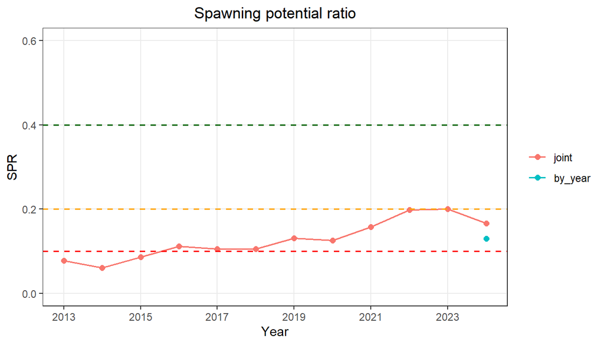

```r
fit_by_year <- fiticc(lfd, stklen, sel_fun = sel_fun, catch_by_gear = cbg,
                      settings = list(CVL = 0.1, obs_model = "dm", dm_theta = "saturating"), by_year = TRUE)

plot_spr(list(joint = fit, by_year = fit_by_year))
```

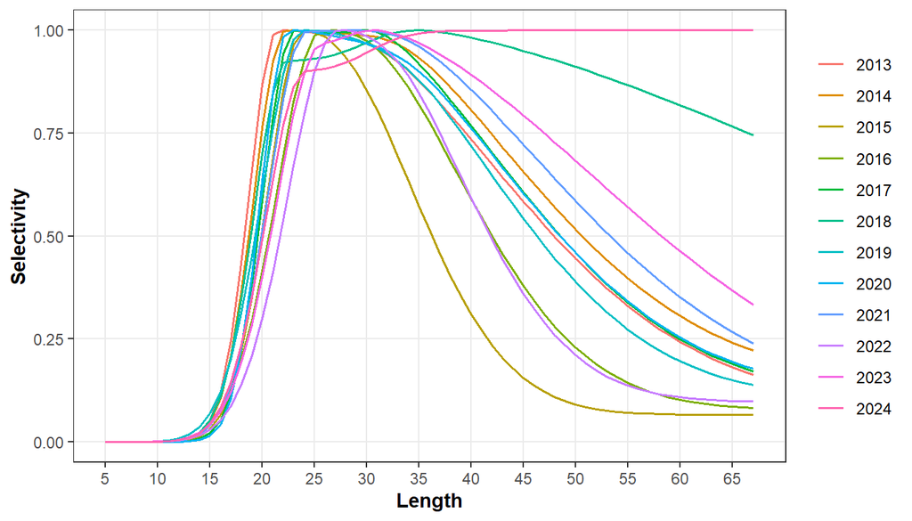

```r
plot_sel(flicc_stklen(fit_by_year))
```

The by-year selectivities differ between years although the gears did not change; these differences are sampling noise taken up by selectivity, and they pass on to F and SPR. The joint fit estimates one selectivity per gear and gives a smoother, more precise SPR series. Use `by_year = TRUE` as a check for real changes in selectivity (a new mesh size, a change of fishing grounds), not as the main assessment.

## 13.6 Lag under changing F

An equilibrium model explains each year’s composition by the equilibrium at that year’s F. After a change in F, the large fish adjust only over many years, so the estimated SPR lags behind (*simulation*, rebuild from 3x to 0.7x Fmsy):

| F model | SPR trend recovered, no cut | with cut at 0.8 Linf |
| --- | --- | --- |
| sigmaF estimated (collapsing) | 14% | 26% |
| sigmaF fixed 0.3 | 27% | 50% |
| sigmaF fixed 1 | 29% | 57% |
| no random walk | 30% | 59% |

The smoothing lag of the random walk is largely removed at sigmaF = 0.3; larger values add little responsiveness but more year-to-year noise (+10 to +50%). The rest of the lag comes from the data (the tail carries the memory of past F) and from recruitment rising during recovery under a stock-recruitment relationship. In a rebuild from deep depletion the equilibrium model stays pessimistic.

# 14 Growth variability and life-history priors

## 14.1 CVL

`CVL` is the coefficient of variation of Linf among growth-type groups. It sets how far individual growth spreads the length composition, mostly in the tail: the fastest-growing groups determine how many fish occur near and beyond Linf. It is fixed at its input value unless `CVL.sd` is given; typical values are 0.07-0.15.

The sensitivity below refits the model for three CVL values (`cvl_values`), without and with a tail cut at 47 cm; `Map()` runs one fit per value.

```r
cvl_values <- c(0.07, 0.10, 0.13)

fits_cvl <- Map(function(cvl) {
  fiticc(lfd, stklen, sel_fun = sel_fun, catch_by_gear = cbg,
         settings = list(CVL = cvl, obs_model = "dm", dm_theta = "saturating"), se = FALSE)
}, cvl_values)
names(fits_cvl) <- paste0("CVL_", cvl_values)

fits_cvl_cut <- Map(function(cvl) {
  fiticc(lfd, stklen, sel_fun = sel_fun, catch_by_gear = cbg,
         settings = list(CVL = cvl, obs_model = "dm", dm_theta = "saturating", tail_cut = 47), se = FALSE)
}, cvl_values)
names(fits_cvl_cut) <- paste0("CVL_", cvl_values, "_cut47")

cvl_table <- data.frame(CVL       = cvl_values,
                        SPR_no_cut = round(sapply(fits_cvl, sprcur_flicc), 3),
                        SPR_cut47  = round(sapply(fits_cvl_cut, sprcur_flicc), 3),
                        row.names = NULL)
cvl_table
```

```
#>    CVL SPR_no_cut SPR_cut47
#> 1 0.07      0.189     0.254
#> 2 0.10      0.166     0.247
#> 3 0.13      0.145     0.236
```

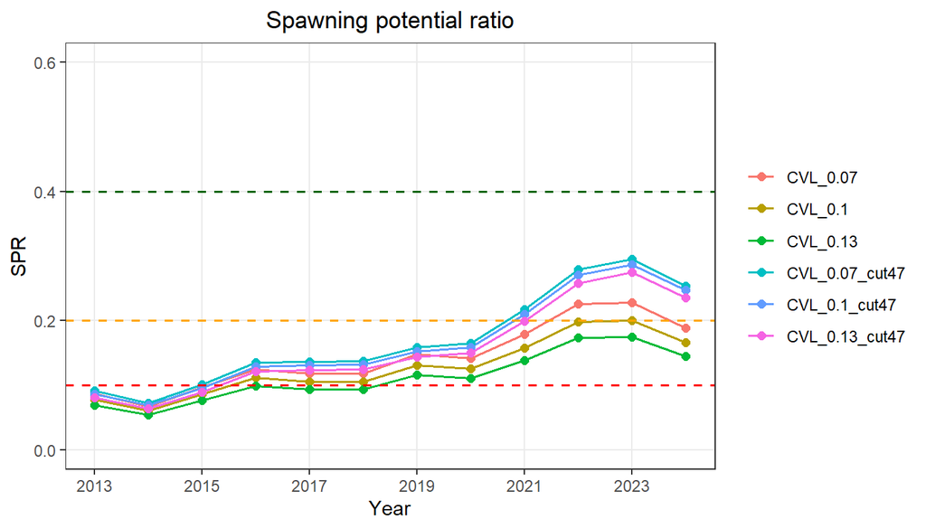

```r
plot_spr(c(fits_cvl, fits_cvl_cut))
```

Status is sensitive to CVL because CVL shapes the tail: here SPR ranges 0.145-0.189 over CVL 0.07-0.13 without a cut and 0.236-0.254 with a cut at 47 cm.

## 14.2 maxsd and ngtg

The growth groups are placed at $z_h$ on `seq(-maxsd, maxsd, length = ngtg)` with normal weights. Truncating the normal at `maxsd` reduces the realised CV of the groups below CVL and caps the largest group at $L_\infty(1 + \text{maxsd}\cdot\text{CVL})$:

The realised spread can be computed directly from the group positions `z` and their normal weights `w`; the factor multiplies CVL:

```r
z <- seq(-2, 2, length.out = 13)          # maxsd = 2, ngtg = 13 (LBSPR)
w <- dnorm(z) / sum(dnorm(z))
sqrt(sum(w * z^2))                        # realised CV factor
```

```
#> [1] 0.9115967
```

```r
z <- seq(-3, 3, length.out = 13)          # maxsd = 3, ngtg = 13 (default)
w <- dnorm(z) / sum(dnorm(z))
sqrt(sum(w * z^2))
```

```
#> [1] 0.9938892
```

```r
55.7 * (1 + c(2, 3) * 0.1)                # largest group Linf for maxsd 2 and 3
```

```
#> [1] 66.84 72.41
```

With the LBSPR default (`maxsd = 2`, 13 groups) the realised CV is about 0.9 x CVL; `maxsd = 3` gives almost exactly CVL and allows larger fish. The number of groups matters little beyond about 13, and computing time grows with it.

The fits below compare LBSPR’s grid with the default and a finer grid (`maxsd_values` with matching `ngtg_values`), without and with the tail cut; `Map()` takes the two vectors in parallel.

```r
maxsd_values <- c(2, 3, 3)
ngtg_values  <- c(13, 13, 19)

fits_maxsd <- Map(function(maxsd, ngtg) {
  fiticc(lfd, stklen, sel_fun = sel_fun, catch_by_gear = cbg,
         settings = list(CVL = 0.1, obs_model = "dm", dm_theta = "saturating", maxsd = maxsd, ngtg = ngtg), se = FALSE)
}, maxsd_values, ngtg_values)

fits_maxsd_cut <- Map(function(maxsd, ngtg) {
  fiticc(lfd, stklen, sel_fun = sel_fun, catch_by_gear = cbg,
         settings = list(CVL = 0.1, obs_model = "dm", dm_theta = "saturating", maxsd = maxsd, ngtg = ngtg,
                         tail_cut = 47), se = FALSE)
}, maxsd_values, ngtg_values)

data.frame(maxsd      = maxsd_values,
           ngtg       = ngtg_values,
           SPR_no_cut = round(sapply(fits_maxsd, sprcur_flicc), 3),
           SPR_cut47  = round(sapply(fits_maxsd_cut, sprcur_flicc), 3))
```

```
#>   maxsd ngtg SPR_no_cut SPR_cut47
#> 1     2   13      0.172     0.250
#> 2     3   13      0.166     0.247
#> 3     3   19      0.166     0.247
```

The default is `maxsd = 3, ngtg = 13` (from FLicc 1.0.11; before: LBSPR’s `maxsd = 2, ngtg = 13`); 19 groups give the same result at about 25% more computing time. With `maxsd = 2` the largest group is $1.2 L_\infty$ at CVL = 0.1, and fish above it get a near-zero probability: each such fish costs about the same in the likelihood. In sensitivity runs and Monte Carlo draws with a lower Linf or CVL, this gives steps in the AIC and failed refits. `maxsd = 3` extends the groups to $1.3 L_\infty$, and CVL is then close to the realised spread, which matters when CVL is taken from external growth studies (with `maxsd = 2`, a CVL input of 0.1 corresponds to a realised spread of about 0.09). At the input life history the two settings usually give similar results. Use `maxsd = 2` to reproduce LBSPR.

## 14.3 Estimating Linf, M/k and CVL with priors

By default growth and natural mortality are fixed. `linf.sd`, `Mk.sd` and `CVL.sd` estimate them with normal priors on the log scale around the inputs:
$$\log L_\infty \sim N(\log L_\infty^{in}, \texttt{linf.sd}^2), \quad
\log (M/k) \sim N(\log (M/k)^{in}, \texttt{Mk.sd}^2), \quad
\log \mathrm{CVL} \sim N(\log \mathrm{CVL}^{in}, \texttt{CVL.sd}^2),$$
so each sd is approximately a CV (e.g. `linf.sd = 0.05`: about ±10% at 95%).

The fit below estimates all three with priors. The estimates are on the log scale: $L_\infty$ = `exp(log_Linf)`, $M/k$ = `exp(log_Mk)` and CVL = `1 / sqrt(exp(log_Galpha))`; the column `se` is approximately the posterior CV (for `log_Galpha` divide by 2).

```r
fit_pri <- fiticc(lfd, stklen, sel_fun = sel_fun, catch_by_gear = cbg,
                  settings = list(CVL = 0.1, obs_model = "dm", dm_theta = "saturating",
                                  linf.sd = 0.05, Mk.sd = 0.1, CVL.sd = 0.25))

est <- fit_pri$par[fit_pri$par$par %in% c("log_Linf", "log_Mk", "log_Galpha"), ]
est
```

```
#>          par       mpd         se
#> 1   log_Linf 3.8968682 0.04119969
#> 2 log_Galpha 4.7193829 0.35243888
#> 3     log_Mk 0.6893467 0.10633810
```

```r
exp(est$mpd[est$par == "log_Linf"])            # Linf (input 55.7)
```

```
#> [1] 49.24797
```

```r
exp(est$mpd[est$par == "log_Mk"])              # M/k  (input 0.162 / 0.08 = 2.03)
```

```
#> [1] 1.992413
```

```r
1 / sqrt(exp(est$mpd[est$par == "log_Galpha"])) # CVL  (input 0.1)
```

```
#> [1] 0.09444936
```

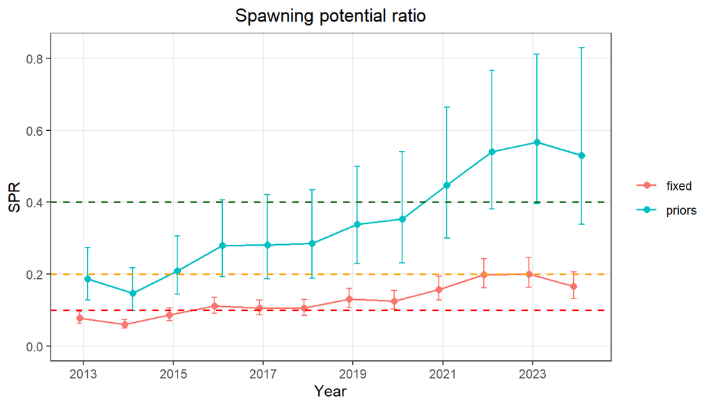

```r
plot_spr(list(fixed = fit, priors = fit_pri), ci = TRUE)
```

Notes:

- **k** is not estimated separately: the length model depends on M/k (and Z/k), so uncertainty in k and M is expressed through `Mk.sd`. k still sets the time scale of the annual F estimates (F is estimated as F/k).
- Length data carry limited information on Linf and CVL, and both are confounded with dome-shaped selectivity and the tail; a posterior CV close to the prior CV means the data are uninformative. Large moves away from the input (several prior SDs) indicate a conflict between the data and the life history, to be investigated rather than accepted.
- For ensembles, drawing the life-history parameters and keeping them fixed in each fit (`mc_flicc()`) is usually better behaved than estimating them.

# 15 Tail of the length composition

## 15.1 Tail cut

`tail_cut = L` excludes bins with lower bound $\geq L$ from the likelihood; observed and predicted compositions are truncated and the predictions renormalised,
$$\pi_{l \mid L < L_{cut}} = \pi_l \Big/ \sum_{l' : L_{l'} < L_{cut}} \pi_{l'} .$$
This is exact conditioning: the model still describes the whole population with its input CVL, SPR and reference points use all lengths, and CVL needs no adjustment. `tail_cut` is an **absolute length** (as `Lplus`), so all sensitivity runs and ensemble draws use the same bins. (Values <= 1.5 are read as a fraction of Linf, with a warning.)

```r
fit_cut <- fiticc(lfd, stklen, sel_fun = sel_fun, catch_by_gear = cbg,
                  settings = list(CVL = 0.1, obs_model = "dm", dm_theta = "saturating", tail_cut = 47))  # ~0.85 x Linf
fit_cut$tmb_data$LLB[fit_cut$tmb_data$cut_bin + 1]
```

```
#> [1] 47
```

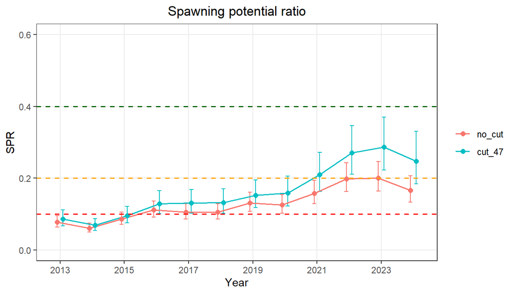

```r
plot_spr(list(no_cut = fit, cut_47 = fit_cut), ci = TRUE)
```

*Simulation* (stable F, correct Linf unless stated):

|  | no cut | cut at 0.80-0.85 x Linf |
| --- | --- | --- |
| CVL input 0.07 / 0.10 / 0.13 (true 0.1) | +9 / -1 / -11% | +13 / +9 / +4% |
| strong dome on one gear fitted as logistic | -17% | +1% |
| SPR trend recovered in a rebuild (sigmaF 0.3) | 27% | ~50% |
| Linf input 0.9 / 1.1 x true | +91 / -40% | +74 / -28% |

The cut halves the CVL sensitivity, removes the bias of a strong unmodelled dome and roughly doubles responsiveness; it costs a small positive bias (+7 to +10%) and more noise under stable F, and does not remove the Linf sensitivity. Starting value: 0.80-0.85 x Linf, fixed across fits.

## 15.2 Plus group, robust likelihood, GTG range

- `Lplus = L` pools bins with lower bound $\geq L$ into one (the total counts, the shape does not).
- `rob_eps = 0.001` bounds the cost of a few fish in bins the model barely reaches.
- The largest growth group stops at $L_\infty(1 + \text{maxsd}\cdot\text{CVL})$ (1.3 Linf with the default `maxsd = 3` and CVL = 0.1). Fish beyond it get near-zero probability, and `fiticc()` warns about them (`tail_warning`, default `TRUE`); a tail cut makes this irrelevant.

# 16 Model equations and comparison of models

## 16.1 Fishing mortality and total mortality

$F_{g,y}(L) = F_{g,y} S_g(L)$, $Z_y(L) = M(L) + \sum_g F_{g,y}(L)$. Gear shares of F are informed by `catch_by_gear` through a soft constraint on the predicted catch shares (`catch.sd`, default 0.05), in weight by default:
$$\log\frac{\hat C^w_{g,y}}{\hat C^w_{G,y}} \sim N\!\left(\log\frac{c_{g,y}}{c_{G,y}},\ \texttt{catch.sd}^2\right),
\qquad \hat C^w_{g,y} = \sum_L C_{g,y}(L)\, W(L),$$
where $c_{g,y}$ is `catch_by_gear` and $G$ the last gear. The predicted shares are in `fit$report$catch_share`. With `settings$catch_units = "numbers"` the shares are compared in numbers, $\hat C_{g,y} = \sum_L C_{g,y}(L)$, as in fishblicc (Medley 2025); use this when the catch split is known in numbers.

## 16.2 Expected catch and length composition

FLicc separates the **population model** (expected numbers at length under growth, M, F and selectivity) from the **observation model** (the likelihood that links the observed counts to the expected composition), so either can be changed without the other. With $N_i$ the expected number of fish entering length bin $i$, the expected catch of gear $g$ in bin $i$ is
$$C_{i,g} = \frac{F_{i,g}}{Z_i}\left(N_i - N_{i+1}\right), \qquad Z_i = M_i + \sum_g F_{i,g},$$
and the expected composition of gear $g$ is $\pi_{i,g} = C_{i,g} / \sum_i C_{i,g}$.

## 16.3 Population model

`pop_model = "gamma"` follows fishblicc: Linf is gamma-distributed among individuals, and the numbers at length integrate survival over that distribution,
$$N_i = \int f(L_\infty)\, S_i(L_\infty)\, dL_\infty ,$$
evaluated by Gauss-Laguerre quadrature (slower). Both are equilibrium models: each year is explained by the equilibrium at that year’s F (section *Lag under changing F* on the consequences).

## 16.4 Observation model

How the sample size enters each of them is explained in section *Effective sample size and observation models*; the models are compared on the same data below.

## 16.5 Comparison of models

The population model (`gtg` or `gamma`) and the observation model (`mn`, `dm`, `nb`) can be combined freely. The four fits below differ only in these two settings; `Map()` runs one fit per list of settings.

```r
model_settings <- list(
  gtg_mn   = list(CVL = 0.1, pop_model = "gtg",   obs_model = "mn"),
  gtg_dm   = list(CVL = 0.1, pop_model = "gtg",   obs_model = "dm", dm_theta = "saturating"),
  gtg_nb   = list(CVL = 0.1, pop_model = "gtg",   obs_model = "nb"),
  gamma_nb = list(CVL = 0.1, pop_model = "gamma", obs_model = "nb"))   # as fishblicc

fits_model <- Map(function(set) {
  fiticc(lfd, stklen, sel_fun = sel_fun, catch_by_gear = cbg, settings = set)
}, model_settings)

data.frame(model    = names(fits_model),
           SPR_last = round(sapply(fits_model, sprcur_flicc), 3),
           se_log   = round(sapply(fits_model, se_logspr), 3),
           row.names = NULL)
```

```
#>      model SPR_last se_log
#> 1   gtg_mn    0.174  0.095
#> 2   gtg_dm    0.166  0.113
#> 3   gtg_nb    0.157  0.105
#> 4 gamma_nb    0.156  0.105
```

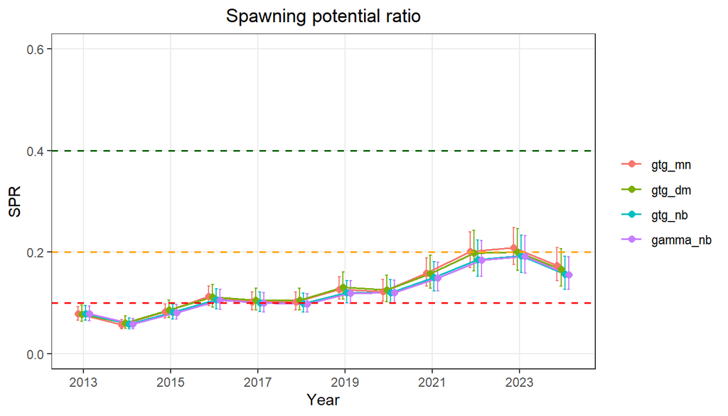

```r
plot_spr(fits_model, ci = TRUE)
```

The gamma model integrates over Linf numerically and is slower:

```r
system.time(fiticc(lfd, stklen, sel_fun = sel_fun, catch_by_gear = cbg,
                   settings = model_settings$gtg_nb))
```

```
#>    user  system elapsed
#>    0.11    0.00    1.56
```

```r
system.time(fiticc(lfd, stklen, sel_fun = sel_fun, catch_by_gear = cbg,
                   settings = model_settings$gamma_nb))
```

```
#>    user  system elapsed
#>    0.75    0.06    7.11
```

Log-likelihoods and AIC are not comparable between observation models (they are likelihoods of different things); compare the estimates, their precision and the fit to the compositions (`plot_len`). Differences between `gtg` and `gamma` show the sensitivity to the approximation of growth variability, differences between `mn`, `dm` and `nb` the weight and robustness given to the compositions.

| Purpose | `pop_model` | `obs_model` | Comment |
| --- | --- | --- | --- |
| Routine assessment, MSE | `"gtg"` | `"dm"` | fast; robust with real data |
| LBSPR-style | `"gtg"` | `"mn"` | fastest; sensitive to the ESS; LBSPR fits each year separately (`by_year = TRUE`) with Linf, M/k and CVL fixed |
| LBB | `"gtg"`, `ngtg = 1` | `"dm"`, fixed precision | `lbb_flicc()`; Reproducing LBB |
| fishblicc replication | `"gamma"` | `"nb"` | slower; closest to fishblicc |

# 17 Reproducing LBSPR, LBB and fishblicc

Each of the three tools is a configuration of FLicc (table in section *FLicc: a framework for length-interval catch curves*). This section fits each tool’s configuration to the tool’s own example data, compares the results with the tool’s published output, and adds FLicc’s default for comparison.

## 17.1 LBSPR: the multi-year example

LBSPR (Hordyk et al. 2015, 2016) fits the GTG model (13 growth-type groups, CV of Linf 0.1, groups over $\pm 2$ SD; FLicc’s default since 1.0.11 is 13 groups over $\pm 3$ SD, so LBSPR’s grid is set explicitly with `ngtg = 13, maxsd = 2`) with a multinomial likelihood to each year separately, with Linf, M/k and CVL fixed, and estimates SL50, SL95 and F/M (apical F over M) by year. The example is LBSPR’s multi-year length-frequency file `LFreq_MultiYrHead.csv` (six years, 5-mm classes) with the life history of LBSPR’s vignette: Linf = 100 mm, M/k = 1.5, L50 = 66 mm, L95 = 70 mm. It is included in FLicc as `data("lbspr_test")`, with LBSPR’s estimates for these data:

```r
data("lbspr_test")   # lfd_lbspr, lhpar_lbspr, lbspr_est
lfd_lbspr
```

```
#> $ LBSPR
#> An object of class "FLQuant"
#> , , unit = unique, season = all, area = unique
#>
#>      year
#> len   2010 2011 2012 2013 2014 2015
#>   0     0    0    0    0    0    0
#>   5     0    0    0    0    0    0
#>   10    0    0    0    0    0    0
#>   15    0    6    0    0    0    0
#>   20    0    0    0    0    0    0
#>   25    6    6    6    0    0    6
#>   30    0    6    6   18   12   18
#>   35   36   42   30   60   30   36
#>   40   78   96   66   42   66   78
```

[output cut: 19 more lines]

```r
lhpar_lbspr          # k only scales F and M; F/M and SPR depend on M/k = 1.5
```

```
#> An object of class "FLPar"
#> params
#>    linf       k       M     L50     L95       a       b
#> 1.0e+02 2.0e-01 3.0e-01 6.6e+01 7.0e+01 1.0e-05 3.0e+00
#> units:  NA
```

```r
stk_lbspr <- stocklen(lfd_lbspr, lhpar_lbspr, m_model = "constant")
```

Three fits: LBSPR’s configuration (multinomial, LBSPR’s growth-type groups, each year separately), the same likelihood and groups with all years fitted jointly (one selectivity, random walk on F), and FLicc’s default (Dirichlet-multinomial with estimated precision, `maxsd = 3`, years jointly). For the separate years `Map()` fits one model per year:

```r
set_lbspr <- list(CVL = 0.1, ngtg = 13, maxsd = 2, obs_model = "mn")
yrs_lbspr <- dimnames(stk_lbspr)$year
fits_lbspr_y <- Map(function(y) {
  lfd_y <- FLQuants(lapply(lfd_lbspr, function(x) x[, y]))
  fiticc(lfd_y, stocklen(lfd_y, lhpar_lbspr, m_model = "constant"), sel_fun = "logistic",
         catch_by_gear = 1, settings = set_lbspr, verbose = FALSE)
}, yrs_lbspr)
fit_lbspr_j <- fiticc(lfd_lbspr, stk_lbspr, sel_fun = "logistic", catch_by_gear = 1,
                      settings = set_lbspr)
fit_lbspr_d <- fiticc(lfd_lbspr, stk_lbspr, sel_fun = "logistic", catch_by_gear = 1,
                      settings = list(CVL = 0.1))
```

LBSPR’s results for these data (`LBSPRfit()`) are in `lbspr_est`: the yearly point estimates, and the estimates smoothed over the years with a Kalman filter (`@Ests`, LBSPR’s default output). The FLicc estimates are taken from the fits (selectivity from the parameters, F/M as apical F over M, SPR):

```r
lbspr_out <- lbspr_est[, c("year", "SL50", "SL95", "FM", "SPR")]
lbspr_smooth <- setNames(lbspr_est[, c("year", "SL50_smooth", "SL95_smooth", "FM_smooth", "SPR_smooth")],
                         c("year", "SL50", "SL95", "FM", "SPR"))
est_flicc <- function(f) {
  sm <- exp(f$obj$env$parList(par = f$obj$env$last.par.best)$Sm) * 100   # relative to Linf
  data.frame(year = as.numeric(f$tmb_data$year_names), SL50 = sm[1], SL95 = sm[1] + sm[2],
             FM = as.numeric(f$report$Fap) / 0.3, SPR = as.numeric(f$report$spr))
}
lbspr_runs <- list("LBSPR, by year" = lbspr_out,
                   "LBSPR, smoothed" = lbspr_smooth,
                   "FLicc mn, by year" = do.call(rbind, lapply(fits_lbspr_y, est_flicc)),
                   "FLicc mn, joint" = est_flicc(fit_lbspr_j),
                   "FLicc default" = est_flicc(fit_lbspr_d))
lbspr_tab <- do.call(rbind, Map(function(x, nm) cbind(run = nm, round(x, 3)), lbspr_runs, names(lbspr_runs)))
rownames(lbspr_tab) <- NULL
lbspr_tab
```

```
#>                  run year   SL50   SL95    FM   SPR
#> 1     LBSPR, by year 2010 49.100 62.900 0.560 0.437
#> 2     LBSPR, by year 2011 48.920 64.580 0.550 0.439
#> 3     LBSPR, by year 2012 48.470 61.440 0.560 0.432
#> 4     LBSPR, by year 2013 49.430 64.730 0.490 0.483
#> 5     LBSPR, by year 2014 50.050 63.370 0.760 0.351
#> 6     LBSPR, by year 2015 46.350 59.790 0.370 0.540
#> 7    LBSPR, smoothed 2010 48.690 62.820 0.550 0.440
#> 8    LBSPR, smoothed 2011 48.700 62.880 0.550 0.440
#> 9    LBSPR, smoothed 2012 48.690 62.760 0.550 0.440
#> 10   LBSPR, smoothed 2013 48.700 62.780 0.550 0.450
#> 11   LBSPR, smoothed 2014 48.630 62.600 0.550 0.450
#> 12   LBSPR, smoothed 2015 48.420 62.340 0.540 0.450
#> 13 FLicc mn, by year 2010 49.350 63.211 0.565 0.404
#> 14 FLicc mn, by year 2011 49.200 64.919 0.561 0.406
```

[output cut: 16 more lines]

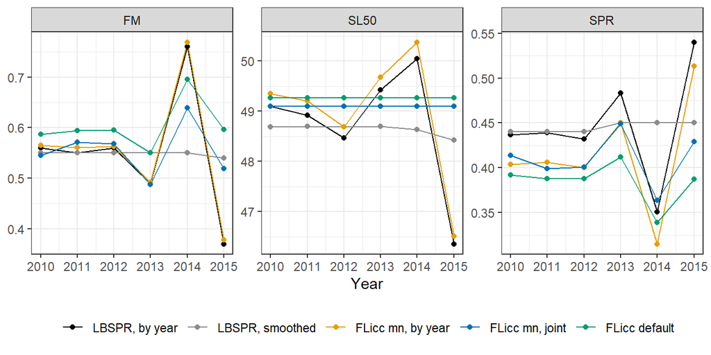

```r
lbspr_long <- do.call(rbind, lapply(c("SL50", "FM", "SPR"), function(v)
  data.frame(lbspr_tab[, c("run", "year")], what = v, value = lbspr_tab[[v]])))
lbspr_long$run <- factor(lbspr_long$run, levels = names(lbspr_runs))
ggplot(lbspr_long, aes(year, value, colour = run)) +
  geom_line() + geom_point() + facet_wrap(~what, scales = "free_y") +
  scale_colour_manual(values = c("black", "grey55", "#E69F00", "#0072B2", "#009E73")) +
  labs(x = "Year", y = NULL, colour = NULL) + theme_bw() + theme(legend.position = "bottom")
```

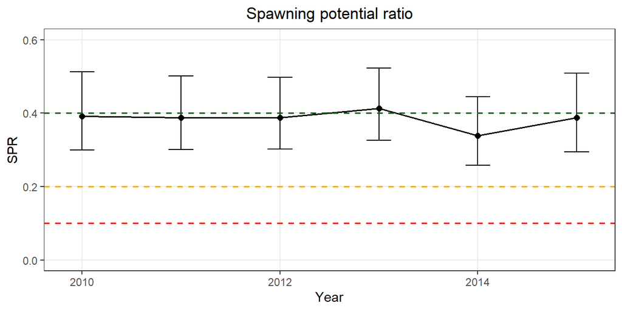

```r
plot_spr(fit_lbspr_d, ci = TRUE)
```

With LBSPR’s configuration (`obs_model = "mn"`, `ngtg = 13`, `maxsd = 2`, each year separately) FLicc reproduces LBSPR’s yearly estimates: SPR differs from LBSPR’s by 0.032 on average, F/M by 0.006. The yearly estimates vary (here SPR from 0.3507105 to 0.5404657 and SL50 from 46.35 to 50.05), and LBSPR smooths them afterwards with a Kalman filter. FLicc’s joint fit links the years inside the model instead: one selectivity for all years and a random walk on F, so the data of all years inform each year’s F through the likelihood rather than by smoothing the point estimates afterwards; the figure compares it with LBSPR’s smoothed series.

At the same SL50, SL95 and F/M, FLicc’s SPR is about 0.03 lower than LBSPR’s in every year. The difference is in the spawning output per recruit, not in the fit, and has two sources in LBSPR’s GTG model (`LBSPRsim_()`):

1. **Selectivity in the survival recursion.** LBSPR computes the selectivity that enters survival as `1/(1 + exp(-log(19) * (LBins - (SL50 + By/2)) / (SL95 - SL50)))` at the class lower bounds `LBins` (`By` = class width), i.e. at one class below the class midpoint, while the predicted catch uses selectivity at the midpoints. Fish are therefore fished as if they were one class (here 5 mm) smaller, which lowers F at length in the survival and raises SPR. The fit, and so SL50 and F/M, is driven by the catch and is not affected.

   > **Note — possible error in LBSPR (`LBSPRsim_.r`, LBSPR 0.1.9):** line 168 evaluates survival selectivity at `LBins - (SL50 + 0.5*By)`, a full class below the midpoint; the M/K line next to it (line 171) uses the midpoint `LBins + 0.5*By`, and the predicted catch (line 218) uses selectivity at the midpoints `LMids`. The model thus applies two selectivity curves one class apart, one to the catch and one to the mortality. The intended expression was probably `(LBins + 0.5*By) - SL50`. As a consequence LBSPR’s SPR is biased upwards by an amount that grows with the class width: for the 2010 estimates (SL50 = 49.1, SL95 = 62.9, F/M = 0.56) LBSPR’s equations give SPR = 0.406, 0.413, 0.437 and 0.483 for 1, 2, 5 and 10-mm classes, against 0.399–0.404 with selectivity at the midpoints. SL50, SL95 and F/M are not affected. LBSPR’s pseudo-age model (`Control = list(modtype = "absel")`) uses midpoints throughout.
2. **Maturity at the same relative size.** LBSPR scales the maturity ogive with each group’s Linf ($L_{50,g} = L_{50}\,L_{\infty,g}/L_\infty$), whereas FLicc uses one maturity-at-length ogive for all groups. Here this changes SPR by only about 0.005, in the opposite direction.

Neither enters the likelihood, so `spr_gtg_flicc()` can recompute the SPR of a GTG fit afterwards: `mat = "relative"` uses LBSPR’s maturity at relative size, and `sel_lag = 1` applies F at length one class late, as in LBSPR’s survival recursion. Both inputs are fixed, so the ratio `adj = spr_gtg / spr` is a correction factor: it scales FLicc’s SPR and its interval and leaves the uncertainty (the SE of log SPR) as it is. With `mat = "length"` and `sel_lag = 0` it returns FLicc’s own SPR (`adj = 1`):

```r
spr_y <- function(f) {
  data.frame(year = as.numeric(f$tmb_data$year_names),
             FLicc = spr_gtg_flicc(f, mat = "length")$spr,
             mat_rel = spr_gtg_flicc(f)$spr_gtg,
             mat_rel_lag = spr_gtg_flicc(f, sel_lag = 1)$spr_gtg)
}
spr_cmp <- do.call(rbind, lapply(fits_lbspr_y, spr_y))
cbind(round(spr_cmp, 3), LBSPR = round(lbspr_out$SPR, 3))
```

```
#>      year FLicc mat_rel mat_rel_lag LBSPR
#> 2010 2010 0.404   0.399       0.436 0.437
#> 2011 2011 0.406   0.401       0.438 0.439
#> 2012 2012 0.400   0.395       0.431 0.432
#> 2013 2013 0.450   0.446       0.481 0.483
#> 2014 2014 0.315   0.310       0.350 0.351
#> 2015 2015 0.513   0.509       0.538 0.540
```

```r
spr_gtg_flicc(fit_lbspr_d, sel_lag = 1)   # joint default fit, LBSPR-type SPR with interval
```

```
#>   year       spr   spr_gtg      adj       lwr       upr
#> 1 2010 0.3915624 0.4227786 1.079722 0.3231389 0.5531422
#> 2 2011 0.3881664 0.4194598 1.080618 0.3250818 0.5412377
#> 3 2012 0.3875531 0.4188602 1.080781 0.3265716 0.5372294
#> 4 2013 0.4122634 0.4429717 1.074487 0.3496501 0.5612008
#> 5 2014 0.3387641 0.3709648 1.095053 0.2825345 0.4870728
#> 6 2015 0.3870813 0.4183989 1.080907 0.3183125 0.5499553
```

With both LBSPR conventions the yearly FLicc SPR differs from LBSPR’s by 0.001 on average, against 0.032 for FLicc’s own SPR. FLicc keeps its own SPR as the default, because it applies the fitted selectivity consistently to the catch and the survival. The default growth-type groups (`maxsd = 3`) also differ from LBSPR’s: they reach 1.3 instead of 1.2 Linf, so a few large fish no longer get a near-zero probability, and CVL is the realised spread of Linf rather than about 0.9 of it (section *maxsd and ngtg*). The default likelihood estimates how much weight the compositions carry and widens the intervals accordingly.

## 17.2 LBB: the Illex example

### 17.2.1 LBB as a special case of the GTG model

LBB (Froese et al. 2018) describes the numbers surviving to length class $j$ (lower bound $L_j$) with one growth type,
$$N_j = N_{j-1}\left(\frac{L_\infty - L_j}{L_\infty - L_{j-1}}\right)^{M/K + (F/K)\,S_j},$$
where $S_j$ is a logistic selectivity with length at 50% selection $L_c$ and slope $\alpha$ (relative to $L_\infty$). This is FLicc’s GTG recursion with a single growth-type group (`pop_model = "gtg"`, `ngtg = 1`). Each year is fitted separately, with a prior on Linf (CV at most 1%, from an `nls()` fit to the aggregated frequencies, or a user value), on M/K (1.5, SD 0.15) and, in LBB, also on $L_c$ and $\alpha$; the likelihood is a Dirichlet on the relative frequencies with a concentration of $10^4$.

The expected catch in a length class can be computed in two ways:

- **with the pile-up correction** (Hordyk et al. 2019; FLicc’s model and LBB with `Pile = 1`): the numbers in the class are the survivors integrated over the time spent in it, $C_j \propto S_j\,(N_j - N_{j+1})/(M/K + (F/K) S_j)$. Fish grow more slowly towards Linf, so they accumulate in the large classes;
- **without it** (LBB `Pile = 0`, the setting of LBB’s example stocks): the catch is proportional to the survivorship at the class bound, $C_j \propto S_j N_j$.

`lbb_flicc()` sets FLicc up as LBB: one growth type, one gear (gears pooled), Linf and M/K priors from `lbb_priors_flicc()` (LBB’s guess step) or user values, lengths at or above the Linf prior excluded, and each year fitted separately (`by_year = TRUE`) or jointly with a random walk on F (`by_year = FALSE`). The options `pile` (LBB’s `Pile`) and `ess` (data weighting; `ess = 20000` with a fixed Dirichlet-multinomial precision corresponds to LBB’s concentration of $10^4$) allow LBB’s settings to be matched. Selectivity is estimated without priors. `lbbref_flicc()` gives LBB’s quantities by year (Linf, Lc, M/K, F/K, F/M, Z/K, Lopt, Lc_opt, B/B0 from LBB’s Beverton-Holt equations) next to FLicc’s EPR and SPR, and `plot_lbb()` LBB’s summary figure.

### 17.2.2 The Illex fit

The example uses LBB’s own example stock *Illex coindetii* (Adriatic) with the settings of LBB’s `Example_ID.csv`: the years 1996, 1999, 2001, 2002, 2009, 2014 and 2016, Linf set to 23 cm, Lm50 16 cm and `Pile = 0`. The data are read from the LBB repository (lengths in mm, converted to cm) and raised to 1000 per year:

```r
url <- "https://raw.githubusercontent.com/SISTA16/LBB/master/Example_Dat.csv"
lbb_dat <- tryCatch(read.csv(url), error = function(e) NULL)
have_lbb <- !is.null(lbb_dat)
if (have_lbb) {
  d <- subset(lbb_dat, Stock == "Ille_coi_AD" & !is.na(CatchNo))
  d <- aggregate(CatchNo ~ Year + Length, data = d, FUN = sum)
  d$data <- d$CatchNo / ave(d$CatchNo, d$Year, FUN = sum) * 1000
  lfd_illex <- FLQuantLen(lfd_long_to_wide(data.frame(len = d$Length / 10, year = d$Year,
                                                      data = d$data, qname = "Illex")),
                          unit = "cm", midL = FALSE)
}
yrs_illex <- c(1996, 1999, 2001, 2002, 2009, 2014, 2016)
```

Three fits: LBB’s settings (`pile = 0`, LBB’s data weighting), the same with the pile-up correction, and FLicc’s joint fit of all years with the pile-up correction and the estimated Dirichlet-multinomial precision:

```r
fit_lbb0 <- lbb_flicc(lfd_illex, Linf = 23, Lm50 = 16, years = yrs_illex,
                      pile = 0, ess = 20000)
fit_lbb1 <- lbb_flicc(lfd_illex, Linf = 23, Lm50 = 16, years = yrs_illex,
                      pile = 1, ess = 20000)
fit_lbbj <- lbb_flicc(lfd_illex, Linf = 23, Lm50 = 16, years = yrs_illex,
                      by_year = FALSE)
fit_lbb0
```

```
#> LBB in FLicc (years fitted separately, logistic selectivity)
#> Linf prior 23 (SD 0.23, user), M/K prior 1.5 (SD 0.15), Z/K guess 1.95, Lmax 23.5, median Lmax 20.5
#>  year Linf   Lc   MK   FM   ZK  BB0  SPR
#>  1996 22.8 13.9 1.55 0.50 2.34 0.57 0.52
#>  1999 21.9  6.0 1.49 1.04 3.03 0.24 0.11
#>  2001 22.9  4.1 1.50 0.60 2.39 0.36 0.24
#>  2002 23.0  4.7 1.49 1.43 3.63 0.15 0.05
#>  2009 23.3  8.8 1.43 1.34 3.35 0.22 0.11
#>  2014 22.6  5.6 1.41 2.65 5.14 0.07 0.01
#>  2016 23.3  6.0 1.48 3.62 6.85 0.05 0.00
#> B/B0 at F = M, Lc = Lc_opt (Bmsy proxy): 0.37
```

LBB’s own results for this stock (`LBB_33a.R`, MCMC medians) are entered as a table and compared by year:

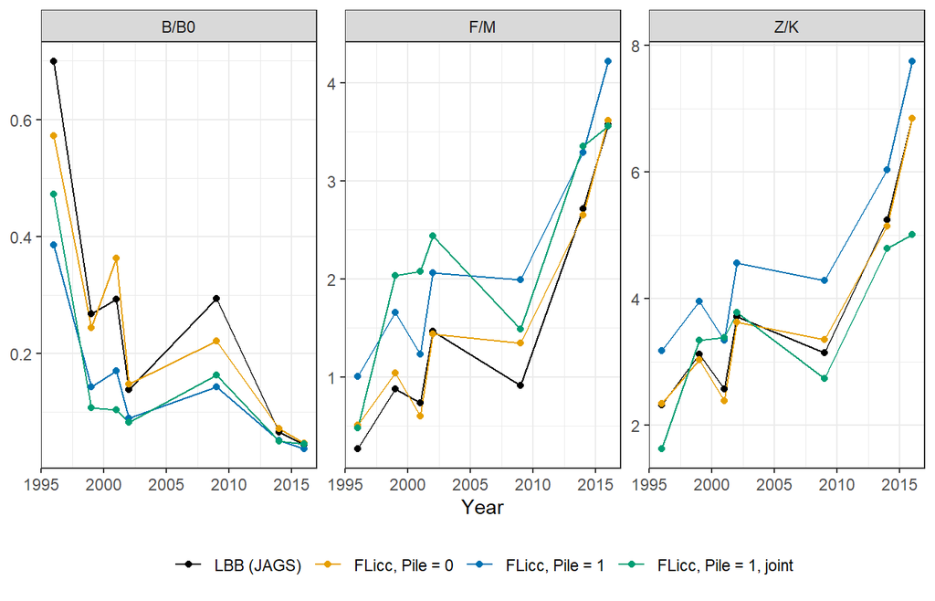

```r
lbb_out <- data.frame(year = yrs_illex,
                      ZK  = c(2.32, 3.12, 2.57, 3.72, 3.15, 5.24, 6.85),
                      FM  = c(0.265, 0.878, 0.732, 1.467, 0.910, 2.713, 3.570),
                      BB0 = c(0.699, 0.267, 0.293, 0.138, 0.294, 0.065, 0.044))
runs <- list("LBB (JAGS)" = lbb_out, "FLicc, Pile = 0" = fit_lbb0$table,
             "FLicc, Pile = 1" = fit_lbb1$table, "FLicc, Pile = 1, joint" = fit_lbbj$table)
cmp <- do.call(rbind, Map(function(x, nm) data.frame(run = nm, year = x$year, ZK = x$ZK,
                                                     FM = x$FM, BB0 = x$BB0), runs, names(runs)))
cmp$run <- factor(cmp$run, levels = names(runs))
long <- rbind(data.frame(cmp[, 1:2], what = "Z/K", value = cmp$ZK),
              data.frame(cmp[, 1:2], what = "F/M", value = cmp$FM),
              data.frame(cmp[, 1:2], what = "B/B0", value = cmp$BB0))
ggplot(long, aes(year, value, colour = run)) +
  geom_line() + geom_point() +
  facet_wrap(~what, scales = "free_y") +
  scale_colour_manual(values = c("black", "#E69F00", "#0072B2", "#009E73")) +
  labs(x = "Year", y = NULL, colour = NULL) +
  theme_bw() + theme(legend.position = "bottom")
```

```r
dif <- function(x) round(mean(x$ZK - lbb_out$ZK), 2)
```

The same comparison with `plot_epr()` and `plot_spr()`: LBB’s B/B0 next to FLicc’s exploitable potential ratio (EPR, the same quantity from the FLicc engine), with LBB’s reference points (B/B0 at F = M and Lc = Lc_opt, a proxy for Bmsy/B0, and half of it), and FLicc’s SPR, which LBB does not report:

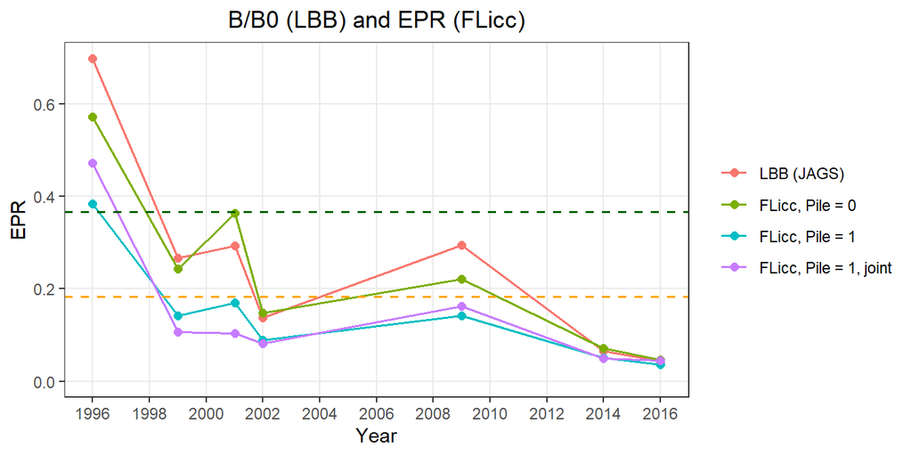

```r
yr_flq <- function(tab, col) FLQuant(matrix(tab[[col]], nrow = 1), dimnames = list(year = tab$year))
bfm <- attr(fit_lbb1$table, "BFM1B0")
plot_epr(FLQuants("LBB (JAGS)" = yr_flq(lbb_out, "BB0"),
                  "FLicc, Pile = 0" = yr_flq(fit_lbb0$table, "EPR"),
                  "FLicc, Pile = 1" = yr_flq(fit_lbb1$table, "EPR"),
                  "FLicc, Pile = 1, joint" = yr_flq(fit_lbbj$table, "EPR")),
         ref_levels = c(bfm, bfm / 2), title = "B/B0 (LBB) and EPR (FLicc)")
```

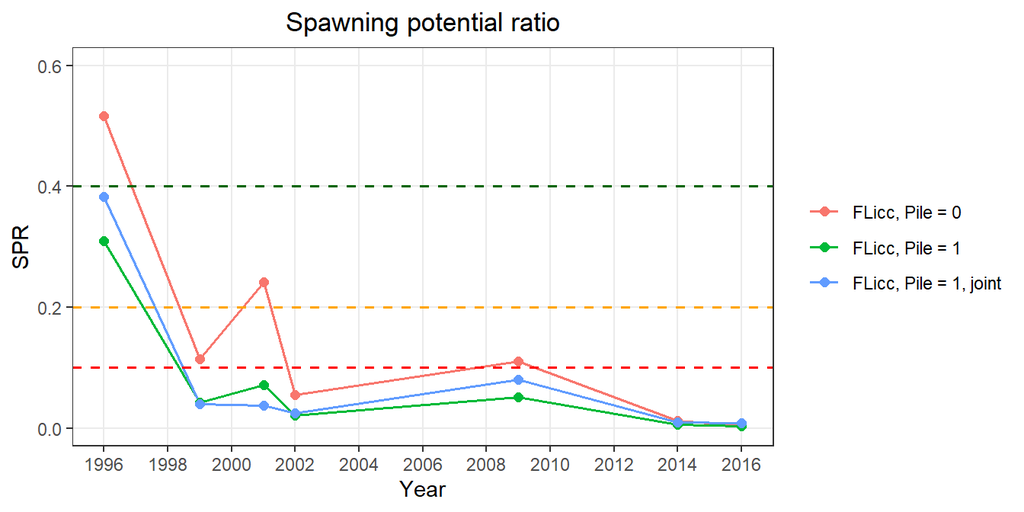

```r
plot_spr(FLQuants("FLicc, Pile = 0" = yr_flq(fit_lbb0$table, "SPR"),
                  "FLicc, Pile = 1" = yr_flq(fit_lbb1$table, "SPR"),
                  "FLicc, Pile = 1, joint" = yr_flq(fit_lbbj$table, "SPR")))
```

With LBB’s settings (`pile = 0`) FLicc reproduces LBB: Z/K differs from LBB’s by -0.03 on average over the years, and F/M and B/B0 follow LBB’s estimates year by year. The remaining differences are small: LBB’s priors on $\alpha$ and F/K shape how Z/K is split into M/K and F/K (LBB’s M/K moves between 1.4 and 1.8 across years, FLicc’s stays near the prior of 1.5), and MCMC medians differ slightly from maximum likelihood estimates.

With the pile-up correction, Z/K is higher by 0.88 on average, so F/M is higher and B/B0 lower. Survivorship declines as about $(L_\infty - L)^{Z/K}$, while the numbers in a class decline as about $(L_\infty - L)^{Z/K - 1}$, so the model without the correction needs a Z/K about one unit lower to describe the same frequencies. The joint fit of all years (`by_year = FALSE`) shares selectivity and links F between years, which smooths the year-to-year changes in the separate fits.

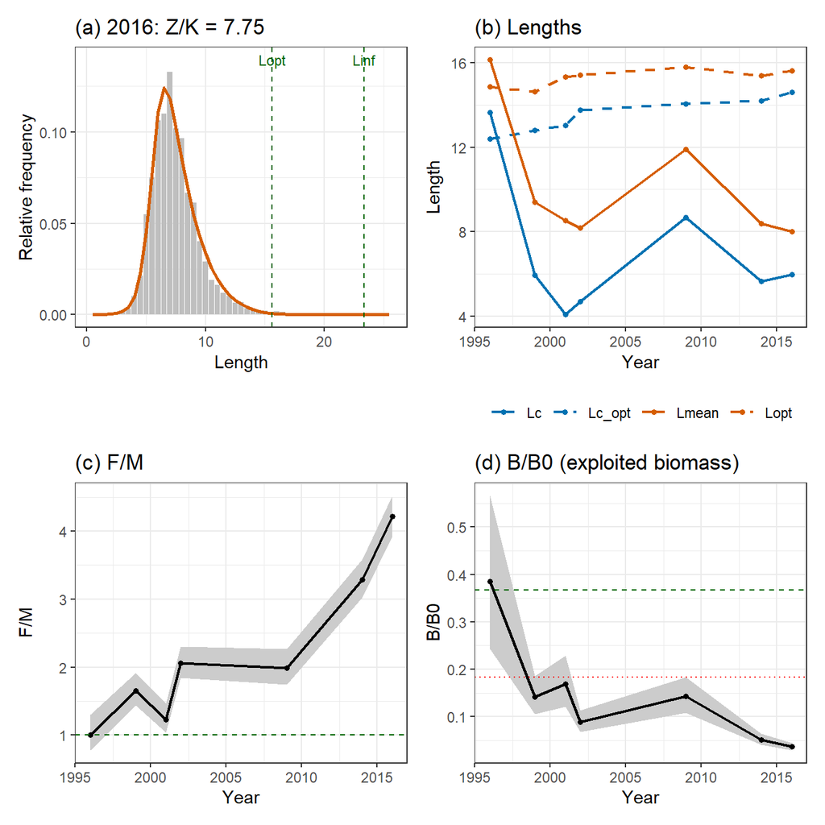

```r
plot_lbb(fit_lbb1)
```

### 17.2.3 Points to consider with LBB

- **Pile-up correction.** Hordyk et al. (2019) pointed out that the numbers in a length class are the survivors integrated over the class, and that without the correction F is underestimated. Froese et al. (2019) argued that the correction matters most for continuous recruitment and sampling, and added it as an option to LBB. In LBB’s B/B0, computed from the Beverton-Holt equations, the integration is included; with `Pile = 0` Z/K is therefore estimated with a different model from the one used for B/B0. FLicc uses the integrated numbers for estimation and status (`pile = 1`, default); `pile = 0` is available to reproduce LBB.
- **Priors.** LBB’s priors on $L_c$ and in particular on $\alpha$ (SD 2.5%, centred on a value derived from each year’s ascending limb) fix much of the selectivity shape; together with the M/K prior they determine the split of Z/K into M/K and F/K, which the data alone barely inform. In FLicc these constraints are optional settings (priors, `sel_fixed`).
- **Separate years.** Fitting each year separately lets selectivity and Linf change between years, which absorbs recruitment pulses as apparent changes in selectivity. The joint fit (`by_year = FALSE`) estimates one selectivity and links F between years.
- **Weighting.** LBB’s Dirichlet concentration of $10^4$ gives the data a weight close to $10^4$ fish per year whatever the sample size; FLicc’s default estimates the precision from the data.

Within these choices, LBB’s estimates can be reproduced in FLicc, and each assumption can be switched separately to see its effect.

## 17.3 fishblicc: the Bombay duck example

FLicc includes the Bombay duck example of fishblicc (three gears) to check consistency with fishblicc. Natural mortality decreases with length (`m_model = "inverse"`, $M(L) = M\, L_{ref} / L$ with $L_{ref} = 21.9$), and Linf, M/k and CVL are estimated with priors as in fishblicc. fishblicc compares the relative catch of each gear in numbers of fish (Medley 2025), so the catch shares are given in numbers here (`catch_units = "numbers"`):

```r
data("fishblicc_example")
lhpar_fishblicc <- rbind(lhpar_fishblicc,
                         FLPar(M = lhpar_fishblicc["k"] * lhpar_fishblicc["Mk"]))
stklen_fishblicc <- stocklen(lfd_fishblicc, lhpar_fishblicc,
                             m_model = "inverse", reflen = 21.9)
```

```r
fit_fishblicc <- fiticc(lfd_fishblicc, stklen_fishblicc,
                        sel_fun = c("dsnormal", "dsnormal", "dsnormal"),
                        catch_by_gear = c(0.1802070, 0.2101353, 0.6096577),
                        settings = list(pop_model = "gamma", obs_model = "nb",
                                        CVL = 0.14, CVL.sd = 0.1,
                                        linf.sd = 2 / 40, Mk.sd = 0.1,
                                        catch_units = "numbers"))
flicc_convergence(fit_fishblicc)
```

```
#>                              check              value passed
#> 2           Gradient is acceptable          6.029e-06   TRUE
#> 3     Hessian is positive definite               TRUE   TRUE
#> 4        Standard errors available 16 / 16 parameters   TRUE
#> 5 Hessian eigenvalues are positive              8.484   TRUE
#> 6   Newton decrement is negligible           1.29e-15   TRUE
#> 7                          Overall                 ok   TRUE
#>                                                                                        interpretation
#> 2                                                             The fit is close to a stationary point.
#> 3                                                                The model curvature is well behaved.
#> 4                                                  Uncertainty could be estimated for all parameters.
#> 5                                             No flat or negative curvature directions were detected.
#> 6 Expected further gain in log-likelihood (0.5 g'H^-1 g) is below 0.001; NA without Newton polishing.
#> 7              ok: converged; warning: usable, but check the gradient or decrement; fail: do not use.
```

```r
sprcur_flicc(fit_fishblicc)
```

```
#> [1] 0.3160299
```

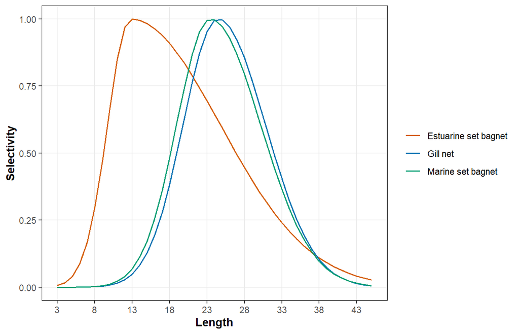

```r
plot_sel(fit_fishblicc)
```

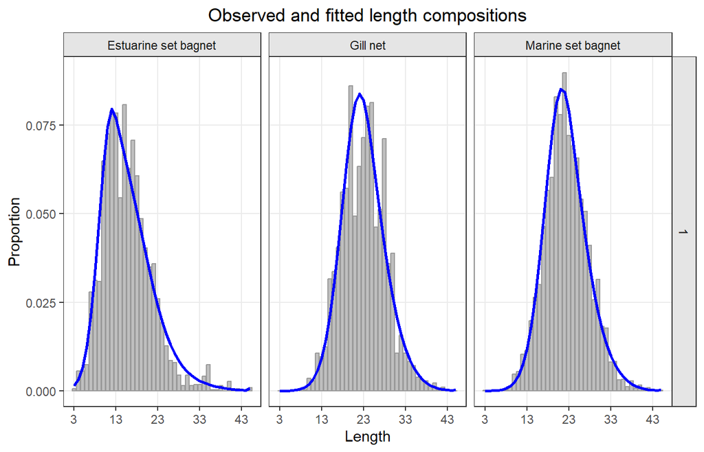

```r
plot_len(fit_fishblicc, by_gear = TRUE)
```

```r
eqstk_fishblicc <- eqstklen(fit_fishblicc, s = 0.7)
eqstk_fishblicc@refpts
```

```
#> An object of class "FLPar"
#> params
#>   Fcur   Fspr   Ycur SSBcur SPRcur   SPR0
#>  1.164  0.910  0.914  0.234  0.316  1.382
#> units:  NA
```

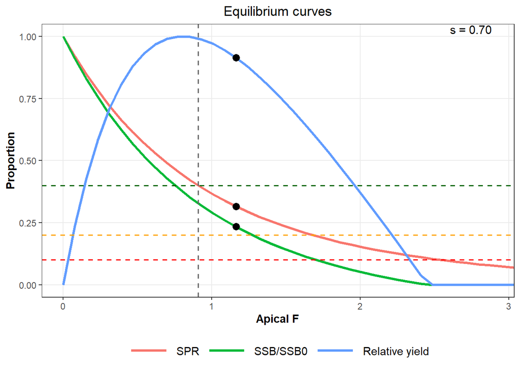

```r
plot_eqcurves(eqstk_fishblicc)
```

# Part III: Management

# 18 Use in an MSE

`flicc.sa()` wraps `fiticc()` as the estimation step of an `mse` management procedure, with `lbi.hcr()`, `rfb.flicc.hcr()` and `flicc.is()` for the harvest control rule and implementation:

```r
est <- mseCtrl(method = flicc.sa, args = list(
  lhpar = lhpar, sel_fun = sel_fun, ess.g = NULL,   # raw counts
  settings = list(obs_model = "dm", dm_theta = "saturating", CVL = 0.1,
                  sigmaF = 0.3,      # fixed (or the F_re estimate from the real data)
                  tail_cut = 47,     # absolute length, the same in every iteration
                  spr_ref = 40),
  spr = 40))
```

- `se = FALSE` is used inside `flicc.sa()`; fixed sigmaF avoids its estimation in every year and iteration.
- The tail cut and sigmaF both trade responsiveness against stability; tune them together with the smoothing of the harvest control rule.
- Expect the equilibrium model to be pessimistic during a rebuild and optimistic while F increases.

# 19 Summary of checks and recommendations

| # | Check | Red flag | Action |
| --- | --- | --- | --- |
| 1 | sample size by gear-year (`plot_lfdn`) | < 50 fish or < 10 bins; gear mix changing | ESS per gear; drop/pool poor gear-years |
| 2 | composition consistency (`plot_lfd`) | shifts in mode or left limb | split gears/periods; restrict years |
| 3 | largest fish vs Linf | > 1% at or above Linf | revisit Linf; tail cut |
| 4 | empirical catch curves (`plot_zlcc`) | curved limbs, jumping slopes | dome or tail cut; keep random walk |
| 5 | life-history inputs (`plot_growth`, `growth_phase_flicc`) | Linf inconsistent with data; odd M/k; largest fish beyond the largest growth group; cohort modes not following the growth curve | Linf sensitivity; priors (`linf.sd`) as a check; maxsd; growth check of k |
| 6 | selectivity plausibility (`plot_sel`) | narrow or unsupported domes | logistic; fix from external data; dome sensitivity (`dome_sens_flicc`) |
| 7 | convergence (`flicc_convergence`) | gradient, Hessian, bounds | restarts; simplify; tail cut |
| 8 | fit to compositions (`plot_len`, `plot_resid_bubble`, `lmean_resid_flicc`, `ppc_flicc`) | systematic misfit; failed runs test; many values outside predictive intervals | selectivity, Linf, tail cut; lower ESS; cohort patterns are expected |
| 9 | retrospective | rho beyond ±0.2 | trends in selectivity or sampling |
| 10 | indicators vs status | gears disagree | best gear; pooling; HCR smoothing |

| Topic | Recommendation |
| --- | --- |
| Observation model | `dm` with real data |
| Sample size | `dm` with `dm_theta = "saturating"` on raw counts or ESS >= 500 (the data set their weight); with fixed precision or `mn`, ESS about 150-200 per gear-year, never raw thousands |
| Single year | `mn` (ESS 150-200 per gear) or `dm` with `dm_theta = "fixed"`: the DM precision is not estimable from one composition per gear (`dm_shared = TRUE` with several gears may work) |
| Growth | fix Linf and CVL; Linf is the main sensitivity; default `maxsd = 3, ngtg = 13` (`maxsd = 2` only to reproduce LBSPR) |
| Selectivity | logistic unless supported; always run `dome_sens_flicc()` (rsd 1000 to 0.4 x Linf); `binormal`/`bidsnormal` for two size modes |
| Sensitivity runs | `fits_summary()` for the table; `ensemble_flicc()` with equal weights (AIC weights as a check, same data only) |
| Management options | `plot_contour_flicc()`: yield and SPR (or SSB with `s`) over selectivity and F by gear |
| F over time | random walk, sigmaF fixed (0.3 or the `F_re` estimate); `by_year = TRUE` only as a check |
| Tail | `tail_cut` at about 0.80-0.85 x Linf, as a length |
| Missing data | keep zeros, rely on the random walk; not without random walk |
| Status | SPR at the year’s F; `s` for $B/B_{tgt}$ under Beverton-Holt; `plot_LBAdvice(flicc2FLStockR(fit))` |
| Models | `gtg` + `dm` routinely; `gamma` + `nb` to replicate fishblicc |
| MSE | fixed sigmaF, absolute tail cut, `se = FALSE`; tune with the HCR |

*Planned: a worked example of a rebuilding stock, refitted year by year, to show how SPR, the tail cut and sigmaF respond over time; estimated Dirichlet-multinomial overdispersion.*

# 20 References

Fournier, D.A., Sibert, J.R., Majkowski, J. and Hampton, J. (1990). MULTIFAN a likelihood-based method for estimating growth parameters and age composition from multiple length frequency data sets illustrated using data for southern bluefin tuna (*Thunnus maccoyii*). Canadian Journal of Fisheries and Aquatic Sciences 47: 301-317.

Froese, R., Winker, H., Coro, G., Demirel, N., Tsikliras, A.C., Dimarchopoulou, D., Scarcella, G., Probst, W.N., Dureuil, M. and Pauly, D. (2018). A new approach for estimating stock status from length frequency data. *ICES Journal of Marine Science* 75(6): 2004-2015. doi:10.1093/icesjms/fsy078. R code: https://github.com/SISTA16/LBB

Froese, R., Winker, H., Coro, G., Demirel, N., Tsikliras, A.C., Dimarchopoulou, D., Scarcella, G., Probst, W.N., Dureuil, M. and Pauly, D. (2019). On the pile-up effect and priors for Linf and M/K: response to a comment by Hordyk et al. on “A new approach for estimating stock status from length frequency data”. *ICES Journal of Marine Science*. doi:10.1093/icesjms/fsy199

Hordyk, A., Ono, K., Valencia, S., Loneragan, N. and Prince, J. (2015). A novel length-based empirical estimation method of spawning potential ratio (SPR), and tests of its performance, for small-scale, data-poor fisheries. *ICES Journal of Marine Science* 72(1): 217-231. doi:10.1093/icesjms/fsu004

Hordyk, A.R., Ono, K., Prince, J.D. and Walters, C.J. (2016). A simple length-structured model based on life history ratios and incorporating size-dependent selectivity: application to spawning potential ratios for data-poor stocks. *Canadian Journal of Fisheries and Aquatic Sciences* 73(12): 1787-1799. doi:10.1139/cjfas-2015-0422

Hordyk, A.R., Prince, J.D., Carruthers, T.R. and Walters, C.J. (2019). Comment on “A new approach for estimating stock status from length frequency data” by Froese et al. (2018). *ICES Journal of Marine Science* 76(2): 457-460. doi:10.1093/icesjms/fsy168

Kell, L.T., Mosqueira, I., Grosjean, P., Fromentin, J.-M., Garcia, D., Hillary, R., Jardim, E., Mardle, S., Pastoors, M.A., Poos, J.J., Scott, F. and Scott, R.D. (2007). FLR: an open-source framework for the evaluation and development of management strategies. *ICES Journal of Marine Science* 64(4): 640-646. doi:10.1093/icesjms/fsm012

Kristensen, K., Nielsen, A., Berg, C.W., Skaug, H. and Bell, B.M. (2016). TMB: automatic differentiation and Laplace approximation. *Journal of Statistical Software* 70(5): 1-21. doi:10.18637/jss.v070.i05

Medley, P.A.H. (2025). A new Bayesian catch curve stock assessment model for the analysis of length data from multi-gear fisheries. *ICES Journal of Marine Science* 82(12): fsaf224. doi:10.1093/icesjms/fsaf224. R package fishblicc: https://github.com/PaulAHMedley/fishblicc

Sampson, D.B. and Scott, R.D. (2011). A spatial model for fishery age-selection at the population level. *Canadian Journal of Fisheries and Aquatic Sciences*. doi:10.1139/f2011-044

Thorson, J.T., Johnson, K.F., Methot, R.D. and Taylor, I.G. (2017). Model-based estimates of effective sample size in stock assessment models using the Dirichlet-multinomial distribution. *Fisheries Research* 192: 84-93. doi:10.1016/j.fishres.2016.06.005

Trijoulet, V., Albertsen, C.M., Kristensen, K., Legault, C.M., Miller, T.J. and Nielsen, A. (2023). Model validation for compositional data in stock assessment models: calculating residuals with correct properties. *Fisheries Research* 257: 106487. doi:10.1016/j.fishres.2022.106487